# Group Work

Group 5

2026-06-03

```r
# 1. Master list of all packages used across EDA, preprocessing, and modelling
pkgs <- c(
  # Core Data & ML
  "tidyverse",      # Includes ggplot2, dplyr, tidyr, etc.
  "caret",          # Unified machine learning workflow
  "randomForest",   # Random Forest models
  "xgboost",        # Native XGBoost implementation
  "nnet",           # Multinomial logistic regression
  "glmnet",         # Penalized logistic regression
  "mgcv",           # Generalized Additive Models (GAMs)
  "splines",        # Spline basis functions

  # Evaluation & Interpretability
  "pROC",           # Multi-class ROC and AUC calculations
  "pdp",            # Partial dependence plots
  "vip",            # Variable importance
  "rpart.plot",     # Visualizing decision trees

  # Visualization & EDA
  "corrplot",       # Correlation heatmaps
  "ggcorrplot",     # Publication-quality correlation matrices
  "gridExtra",      # Arranging multiple ggplots side-by-side
  "ggridges",       # Ridgeline density plots

  # Stats & Utilities
  "readxl",         # Reading the Excel dataset
  "psych",          # Detailed summary statistics (describe)
  "nortest",        # Formal normality tests (Anderson-Darling)
  "car",            # Variance Inflation Factor (VIF) checks
  "MASS"            # Box-Cox transformations
)

# 2. Automatically install any packages you don't already have
missing_pkgs <- pkgs[!(pkgs %in% installed.packages()[, "Package"])]
if (length(missing_pkgs) > 0) {
  message("Installing missing packages: ", paste(missing_pkgs, collapse = ", "))
  install.packages(missing_pkgs, dependencies = TRUE)
}

# 3. Load all packages cleanly without cluttering your presentation document
invisible(lapply(pkgs, require, character.only = TRUE))

cat("All required packages successfully installed and loaded!\n")
```

```
## All required packages successfully installed and loaded!
```

Description of the variables in the data * $X_1$ Relative Compactness * $X_2$ Surface Area * $X_3$ Wall Area * $X_4$ Roof Area * $X_5$ Overall Height * $X_6$ Orientation * $X_7$ Glazing Area * $X_8$ Glazing Area Distribution * $Y_1$ Heating Load * $Y_2$ Cooling Load

### Policy Context & Analytical Goals

This analysis is designed for **policy makers, city planners, and building regulators**. Rather than predicting exact energy loads (which is useful for HVAC design but less actionable for policy), we will **classify** buildings into energy performance categories (e.g., Low, Medium, High Load).

This categorization enables: 1. **Targeted Retrofitting**: Identifying buildings that fall into the “High Load” category to prioritize for energy-efficient upgrades, maximizing ROI for energy savings. 2. **Demand Response Strategy**: Grouping buildings by load characteristics to aid utility companies in load-shedding strategies during peak demand. 3. **Simplified Decision Support**: Creating clear, categorical insights (“Compliant” vs “Non-Compliant”) that are directly interpretable by non-technical stakeholders.

```r
df <- read_excel("/Users/joe/final_project/data/ENB2012_data 2.xlsx")
head(df)
```

```
## # A tibble: 6 × 10
##      X1    X2    X3    X4    X5    X6    X7    X8    Y1    Y2
##   <dbl> <dbl> <dbl> <dbl> <dbl> <dbl> <dbl> <dbl> <dbl> <dbl>
## 1  0.98  514.  294   110.     7     2     0     0  15.6  21.3
## 2  0.98  514.  294   110.     7     3     0     0  15.6  21.3
## 3  0.98  514.  294   110.     7     4     0     0  15.6  21.3
## 4  0.98  514.  294   110.     7     5     0     0  15.6  21.3
## 5  0.9   564.  318.  122.     7     2     0     0  20.8  28.3
## 6  0.9   564.  318.  122.     7     3     0     0  21.5  25.4
```

```r
colnames(df) <- c(
  "RelCompactness",   # X1
  "SurfaceArea",      # X2
  "WallArea",         # X3
  "RoofArea",         # X4
  "OverallHeight",    # X5
  "Orientation",      # X6
  "GlazingArea",      # X7
  "GlazingAreaDist",  # X8
  "HeatingLoad",      # Y1
  "CoolingLoad"       # Y2
)
```

```r
summary(df)
```

```
##  RelCompactness    SurfaceArea       WallArea        RoofArea
##  Min.   :0.6200   Min.   :514.5   Min.   :245.0   Min.   :110.2
##  1st Qu.:0.6825   1st Qu.:606.4   1st Qu.:294.0   1st Qu.:140.9
##  Median :0.7500   Median :673.8   Median :318.5   Median :183.8
##  Mean   :0.7642   Mean   :671.7   Mean   :318.5   Mean   :176.6
##  3rd Qu.:0.8300   3rd Qu.:741.1   3rd Qu.:343.0   3rd Qu.:220.5
##  Max.   :0.9800   Max.   :808.5   Max.   :416.5   Max.   :220.5
##  OverallHeight   Orientation    GlazingArea     GlazingAreaDist  HeatingLoad
##  Min.   :3.50   Min.   :2.00   Min.   :0.0000   Min.   :0.000   Min.   : 6.01
##  1st Qu.:3.50   1st Qu.:2.75   1st Qu.:0.1000   1st Qu.:1.750   1st Qu.:12.99
##  Median :5.25   Median :3.50   Median :0.2500   Median :3.000   Median :18.95
##  Mean   :5.25   Mean   :3.50   Mean   :0.2344   Mean   :2.812   Mean   :22.31
##  3rd Qu.:7.00   3rd Qu.:4.25   3rd Qu.:0.4000   3rd Qu.:4.000   3rd Qu.:31.67
##  Max.   :7.00   Max.   :5.00   Max.   :0.4000   Max.   :5.000   Max.   :43.10
##   CoolingLoad
##  Min.   :10.90
##  1st Qu.:15.62
##  Median :22.08
##  Mean   :24.59
##  3rd Qu.:33.13
##  Max.   :48.03
```

```r
df_orig <- read_excel("/Users/joe/final_project/data/ENB2012_data 2.xlsx")
```

```r
cat("Dimensions:", dim(df), "\n")
```

```
## Dimensions: 768 10
```

```r
str(df)
```

```
## tibble [768 × 10] (S3: tbl_df/tbl/data.frame)
##  $ RelCompactness : num [1:768] 0.98 0.98 0.98 0.98 0.9 0.9 0.9 0.9 0.86 0.86 ...
##  $ SurfaceArea    : num [1:768] 514 514 514 514 564 ...
##  $ WallArea       : num [1:768] 294 294 294 294 318 ...
##  $ RoofArea       : num [1:768] 110 110 110 110 122 ...
##  $ OverallHeight  : num [1:768] 7 7 7 7 7 7 7 7 7 7 ...
##  $ Orientation    : num [1:768] 2 3 4 5 2 3 4 5 2 3 ...
##  $ GlazingArea    : num [1:768] 0 0 0 0 0 0 0 0 0 0 ...
##  $ GlazingAreaDist: num [1:768] 0 0 0 0 0 0 0 0 0 0 ...
##  $ HeatingLoad    : num [1:768] 15.6 15.6 15.6 15.6 20.8 ...
##  $ CoolingLoad    : num [1:768] 21.3 21.3 21.3 21.3 28.3 ...
```

```r
head(df, 10)
```

```
## # A tibble: 10 × 10
##    RelCompactness SurfaceArea WallArea RoofArea OverallHeight Orientation
##             <dbl>       <dbl>    <dbl>    <dbl>         <dbl>       <dbl>
##  1           0.98        514.     294      110.             7           2
##  2           0.98        514.     294      110.             7           3
##  3           0.98        514.     294      110.             7           4
##  4           0.98        514.     294      110.             7           5
##  5           0.9         564.     318.     122.             7           2
##  6           0.9         564.     318.     122.             7           3
##  7           0.9         564.     318.     122.             7           4
##  8           0.9         564.     318.     122.             7           5
##  9           0.86        588      294      147              7           2
## 10           0.86        588      294      147              7           3
## # ℹ 4 more variables: GlazingArea <dbl>, GlazingAreaDist <dbl>,
## #   HeatingLoad <dbl>, CoolingLoad <dbl>
```

```r
tail(df, 10)
```

```
## # A tibble: 10 × 10
##    RelCompactness SurfaceArea WallArea RoofArea OverallHeight Orientation
##             <dbl>       <dbl>    <dbl>    <dbl>         <dbl>       <dbl>
##  1           0.66        760.     318.     220.           3.5           4
##  2           0.66        760.     318.     220.           3.5           5
##  3           0.64        784      343      220.           3.5           2
##  4           0.64        784      343      220.           3.5           3
##  5           0.64        784      343      220.           3.5           4
##  6           0.64        784      343      220.           3.5           5
##  7           0.62        808.     368.     220.           3.5           2
##  8           0.62        808.     368.     220.           3.5           3
##  9           0.62        808.     368.     220.           3.5           4
## 10           0.62        808.     368.     220.           3.5           5
## # ℹ 4 more variables: GlazingArea <dbl>, GlazingAreaDist <dbl>,
## #   HeatingLoad <dbl>, CoolingLoad <dbl>
```

```r
library(psych)
psych::describe(df)
```

```
##                 vars   n   mean    sd median trimmed    mad    min    max
## RelCompactness     1 768   0.76  0.11   0.75    0.76   0.12   0.62   0.98
## SurfaceArea        2 768 671.71 88.09 673.75  673.75 108.97 514.50 808.50
## WallArea           3 768 318.50 43.63 318.50  315.95  36.32 245.00 416.50
## RoofArea           4 768 176.60 45.17 183.75  179.14  54.49 110.25 220.50
## OverallHeight      5 768   5.25  1.75   5.25    5.25   2.59   3.50   7.00
## Orientation        6 768   3.50  1.12   3.50    3.50   1.48   2.00   5.00
## GlazingArea        7 768   0.23  0.13   0.25    0.24   0.22   0.00   0.40
## GlazingAreaDist    8 768   2.81  1.55   3.00    2.84   1.48   0.00   5.00
## HeatingLoad        9 768  22.31 10.09  18.95   21.71  11.14   6.01  43.10
## CoolingLoad       10 768  24.59  9.51  22.08   23.95  11.18  10.90  48.03
##                  range  skew kurtosis   se
## RelCompactness    0.36  0.49    -0.72 0.00
## SurfaceArea     294.00 -0.12    -1.07 3.18
## WallArea        171.50  0.53     0.10 1.57
## RoofArea        110.25 -0.16    -1.78 1.63
## OverallHeight     3.50  0.00    -2.00 0.06
## Orientation       3.00  0.00    -1.36 0.04
## GlazingArea       0.40 -0.06    -1.33 0.00
## GlazingAreaDist   5.00 -0.09    -1.15 0.06
## HeatingLoad      37.09  0.36    -1.25 0.36
## CoolingLoad      37.13  0.39    -1.15 0.34
```

```r
cat("\nMissing values per column:\n")
```

```
##
## Missing values per column:
```

```r
colSums(is.na(df))
```

```
##  RelCompactness     SurfaceArea        WallArea        RoofArea   OverallHeight
##               0               0               0               0               0
##     Orientation     GlazingArea GlazingAreaDist     HeatingLoad     CoolingLoad
##               0               0               0               0               0
```

```r
cat("\nTotal missing:", sum(is.na(df)), "\n")
```

```
##
## Total missing: 0
```

```r
cat("Duplicated rows:", sum(duplicated(df)), "\n")
```

```
## Duplicated rows: 0
```

```r
# View some duplicates if they exist
if (sum(duplicated(df)) > 0) {
  df[duplicated(df) | duplicated(df, fromLast = TRUE), ] %>%
    arrange(RelCompactness, SurfaceArea) %>%
    head(20)
}
```

# 2.7 Unique value counts per variable

```r
sapply(df, function(x) length(unique(x)))
```

```
##  RelCompactness     SurfaceArea        WallArea        RoofArea   OverallHeight
##              12              12               7               4               2
##     Orientation     GlazingArea GlazingAreaDist     HeatingLoad     CoolingLoad
##               4               4               6             587             636
```

# 2.8 Data types check

```r
sapply(df, class)
```

```
##  RelCompactness     SurfaceArea        WallArea        RoofArea   OverallHeight
##       "numeric"       "numeric"       "numeric"       "numeric"       "numeric"
##     Orientation     GlazingArea GlazingAreaDist     HeatingLoad     CoolingLoad
##       "numeric"       "numeric"       "numeric"       "numeric"       "numeric"
```

# Note: OverallHeight has only 2 levels (3.5, 7.0) — essentially binary

# Orientation has 4 levels (2,3,4,5) — categorical

# GlazingArea has 4 levels (0, 0.1, 0.25, 0.4) — ordinal/categorical

# GlazingAreaDist has 6 levels (0–5) — categorical

```r
# Convert appropriate variables to factors for certain analyses
df$Orientation_f     <- factor(df$Orientation)
df$OverallHeight_f   <- factor(df$OverallHeight, labels = c("Low_3.5m", "High_7m"))
df$GlazingArea_f     <- factor(df$GlazingArea)
df$GlazingAreaDist_f <- factor(df$GlazingAreaDist)
```

```r
sapply(df, class)
```

```
##    RelCompactness       SurfaceArea          WallArea          RoofArea
##         "numeric"         "numeric"         "numeric"         "numeric"
##     OverallHeight       Orientation       GlazingArea   GlazingAreaDist
##         "numeric"         "numeric"         "numeric"         "numeric"
##       HeatingLoad       CoolingLoad     Orientation_f   OverallHeight_f
##         "numeric"         "numeric"          "factor"          "factor"
##     GlazingArea_f GlazingAreaDist_f
##          "factor"          "factor"
```

```r
head(df)
```

```
## # A tibble: 6 × 14
##   RelCompactness SurfaceArea WallArea RoofArea OverallHeight Orientation
##            <dbl>       <dbl>    <dbl>    <dbl>         <dbl>       <dbl>
## 1           0.98        514.     294      110.             7           2
## 2           0.98        514.     294      110.             7           3
## 3           0.98        514.     294      110.             7           4
## 4           0.98        514.     294      110.             7           5
## 5           0.9         564.     318.     122.             7           2
## 6           0.9         564.     318.     122.             7           3
## # ℹ 8 more variables: GlazingArea <dbl>, GlazingAreaDist <dbl>,
## #   HeatingLoad <dbl>, CoolingLoad <dbl>, Orientation_f <fct>,
## #   OverallHeight_f <fct>, GlazingArea_f <fct>, GlazingAreaDist_f <fct>
```

# 3.1 Histograms for all continuous variables

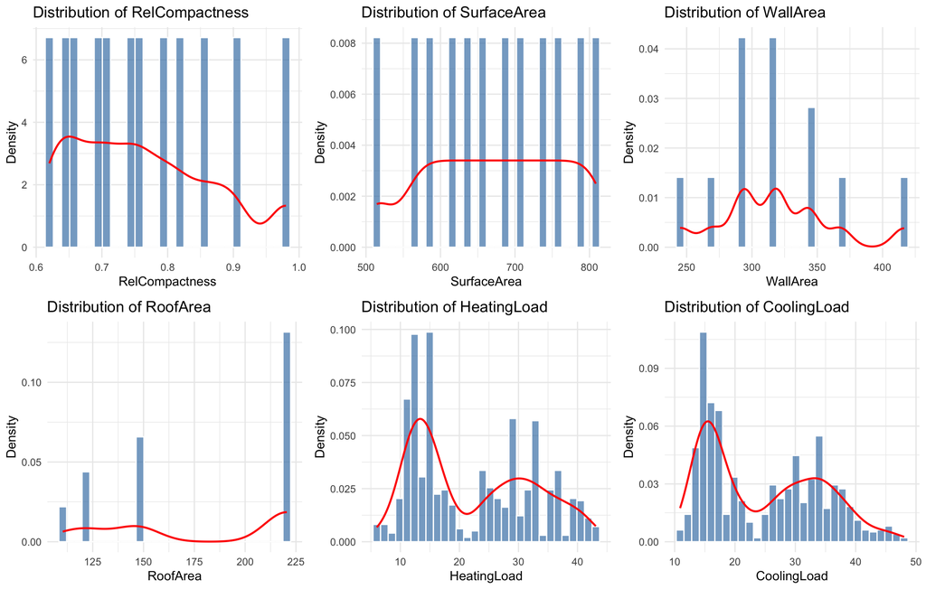

```r
cont_vars <- c("RelCompactness", "SurfaceArea", "WallArea", "RoofArea",
               "HeatingLoad", "CoolingLoad")

p_hist <- list()
for (v in cont_vars) {
  p_hist[[v]] <- ggplot(df, aes(x = .data[[v]])) +
    geom_histogram(aes(y = after_stat(density)), bins = 30,
                   fill = "steelblue", color = "white", alpha = 0.7) +
    geom_density(color = "red", linewidth = 0.8) +
    labs(title = paste("Distribution of", v), x = v, y = "Density") +
    theme_minimal(base_size = 11)
}
do.call(grid.arrange, c(p_hist, ncol = 3))
```

# 3.2 Boxplots for all numeric variables

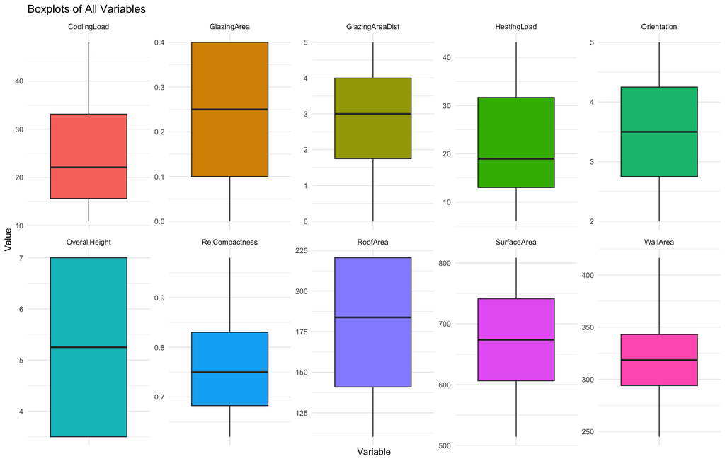

```r
library(tidyverse)
df_long <- df %>%
  dplyr::select(RelCompactness:CoolingLoad) %>%
  pivot_longer(everything(), names_to = "Variable", values_to = "Value")

ggplot(df_long, aes(x = Variable, y = Value, fill = Variable)) +
  geom_boxplot(outlier.colour = "red", outlier.size = 1.5) +
  facet_wrap(~ Variable, scales = "free", ncol = 5) +
  theme_minimal(base_size = 10) +
  theme(legend.position = "none",
        axis.text.x = element_blank()) +
  labs(title = "Boxplots of All Variables")
```

# 3.3 Bar charts for categorical/discrete variables

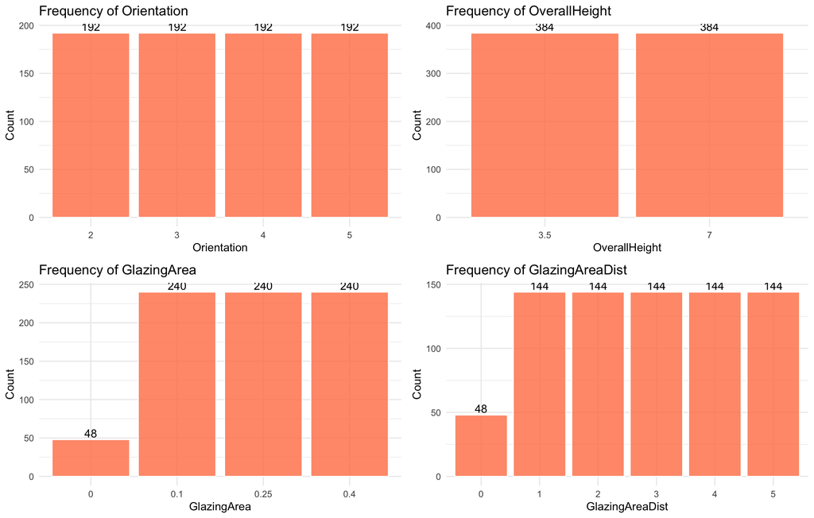

```r
cat_vars <- c("Orientation", "OverallHeight", "GlazingArea", "GlazingAreaDist")

p_bar <- list()
for (v in cat_vars) {
  p_bar[[v]] <- ggplot(df, aes(x = factor(.data[[v]]))) +
    geom_bar(fill = "coral", color = "white", alpha = 0.8) +
    geom_text(stat = "count", aes(label = after_stat(count)), vjust = -0.3) +
    labs(title = paste("Frequency of", v), x = v, y = "Count") +
    theme_minimal(base_size = 11)
}
do.call(grid.arrange, c(p_bar, ncol = 2))
```

# 3.4 QQ-plots for normality assessment of Y1 and Y2

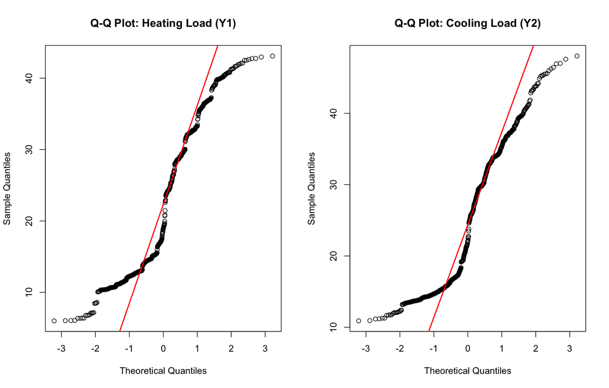

```r
par(mfrow = c(1, 2))
qqnorm(df$HeatingLoad, main = "Q-Q Plot: Heating Load (Y1)")
qqline(df$HeatingLoad, col = "red", lwd = 2)

qqnorm(df$CoolingLoad, main = "Q-Q Plot: Cooling Load (Y2)")
qqline(df$CoolingLoad, col = "red", lwd = 2)
```

```r
par(mfrow = c(1, 1))
```

# 3.5 Formal normality tests on the responses

```r
cat("Shapiro-Wilk test for Y1 (Heating Load):\n")
```

```
## Shapiro-Wilk test for Y1 (Heating Load):
```

```r
shapiro.test(df$HeatingLoad[1:5000])  # Shapiro max 5000 obs, sample if needed
```

```
##
##  Shapiro-Wilk normality test
##
## data:  df$HeatingLoad[1:5000]
## W = 0.9121, p-value < 2.2e-16
```

```r
# If n > 5000, use Anderson-Darling:
nortest::ad.test(df$HeatingLoad)
```

```
##
##  Anderson-Darling normality test
##
## data:  df$HeatingLoad
## A = 26.863, p-value < 2.2e-16
```

```r
cat("\nShapiro-Wilk test for Y2 (Cooling Load):\n")
```

```
##
## Shapiro-Wilk test for Y2 (Cooling Load):
```

```r
shapiro.test(df$CoolingLoad)
```

```
##
##  Shapiro-Wilk normality test
##
## data:  df$CoolingLoad
## W = 0.90904, p-value < 2.2e-16
```

```r
nortest::ad.test(df$CoolingLoad)
```

```
##
##  Anderson-Darling normality test
##
## data:  df$CoolingLoad
## A = 27.122, p-value < 2.2e-16
```

# 3.6 Ridgeline plots — distribution by OverallHeight

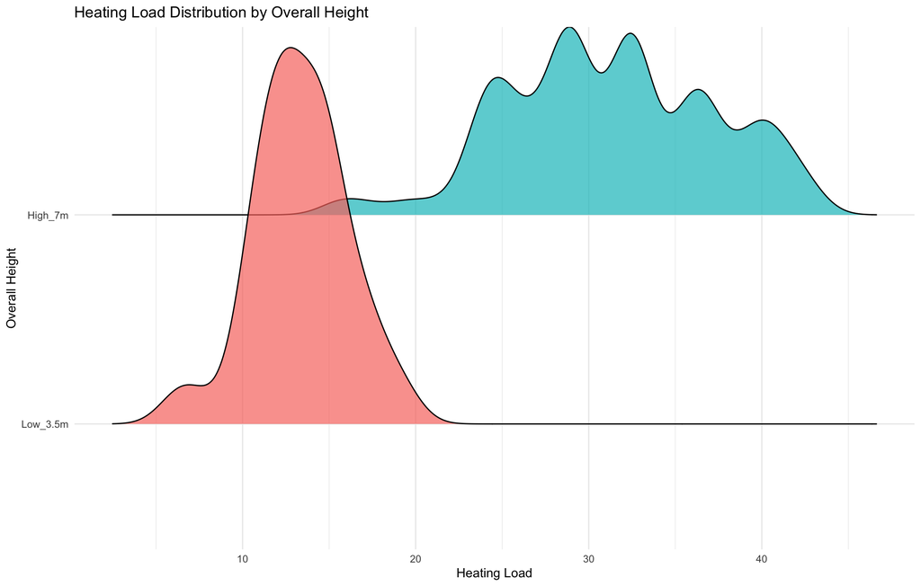

```r
library(ggridges)
ggplot(df, aes(x = HeatingLoad, y = OverallHeight_f, fill = OverallHeight_f)) +
  geom_density_ridges(alpha = 0.7) +
  labs(title = "Heating Load Distribution by Overall Height",
       x = "Heating Load", y = "Overall Height") +
  theme_minimal() +
  theme(legend.position = "none")
```

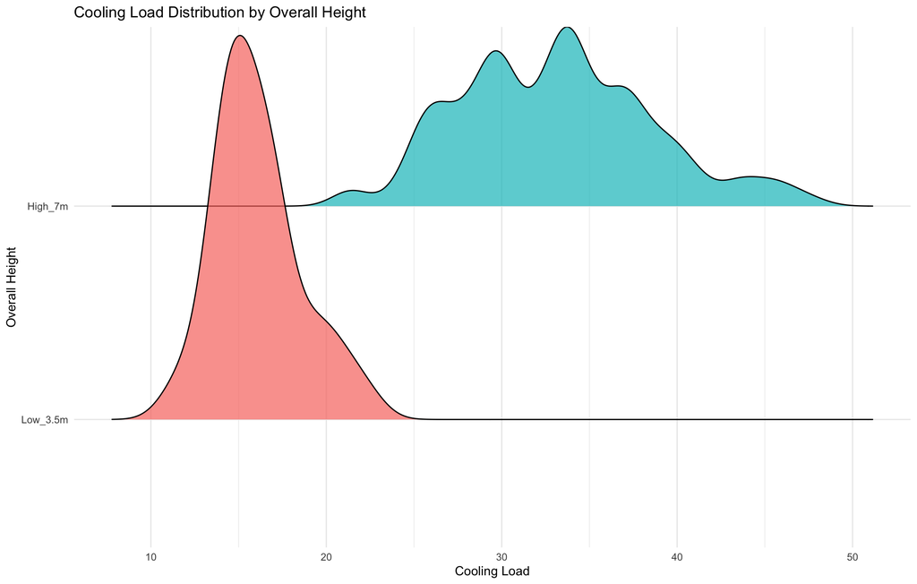

```r
ggplot(df, aes(x = CoolingLoad, y = OverallHeight_f, fill = OverallHeight_f)) +
  geom_density_ridges(alpha = 0.7) +
  labs(title = "Cooling Load Distribution by Overall Height",
       x = "Cooling Load", y = "Overall Height") +
  theme_minimal() +
  theme(legend.position = "none")
```

# 4.1 Scatter plots: each X vs Y1 and Y2

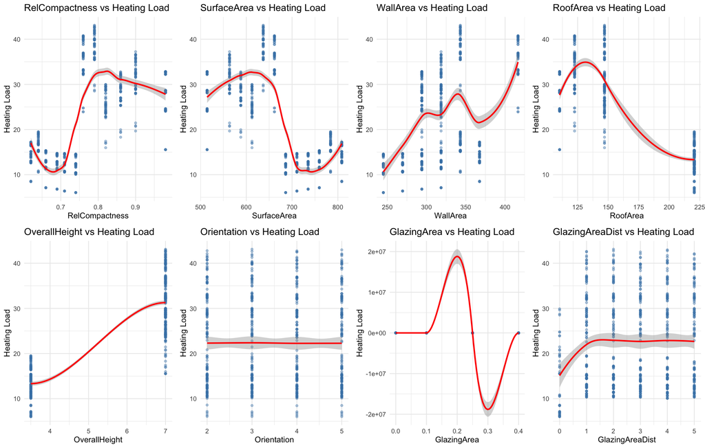

```r
feature_vars <- c("RelCompactness", "SurfaceArea", "WallArea", "RoofArea",
                  "OverallHeight", "Orientation", "GlazingArea", "GlazingAreaDist")

# --- Against Heating Load ---
p_scat_y1 <- list()
for (v in feature_vars) {
  p_scat_y1[[v]] <- ggplot(df, aes(x = .data[[v]], y = HeatingLoad)) +
    geom_point(alpha = 0.4, color = "steelblue", size = 1) +
    geom_smooth(method = "loess", color = "red", se = TRUE, linewidth = 0.8) +
    labs(title = paste(v, "vs Heating Load"), x = v, y = "Heating Load") +
    theme_minimal(base_size = 9)
}
do.call(grid.arrange, c(p_scat_y1, ncol = 4))
```

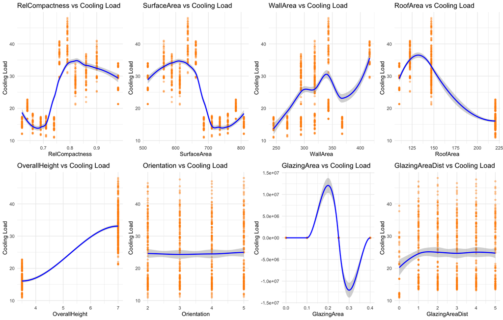

```r
# --- Against Cooling Load ---
p_scat_y2 <- list()
for (v in feature_vars) {
  p_scat_y2[[v]] <- ggplot(df, aes(x = .data[[v]], y = CoolingLoad)) +
    geom_point(alpha = 0.4, color = "darkorange", size = 1) +
    geom_smooth(method = "loess", color = "blue", se = TRUE, linewidth = 0.8) +
    labs(title = paste(v, "vs Cooling Load"), x = v, y = "Cooling Load") +
    theme_minimal(base_size = 9)
}
do.call(grid.arrange, c(p_scat_y2, ncol = 4))
```

The heating load is the amount of heat energy the building loses to the outside environment. To maintain a steady indoor temperature (e.g., 20°C), the heating system must produce enough heat to replace what is lost.

The cooling load is the amount of heat energy the building gains from the outside environment and internal sources. The air conditioning system must remove this excess heat to keep the indoor temperature at a comfortable level.

### Physical Design Variables & Policy Impact

# 4.2 Scatter with colour by Overall Height

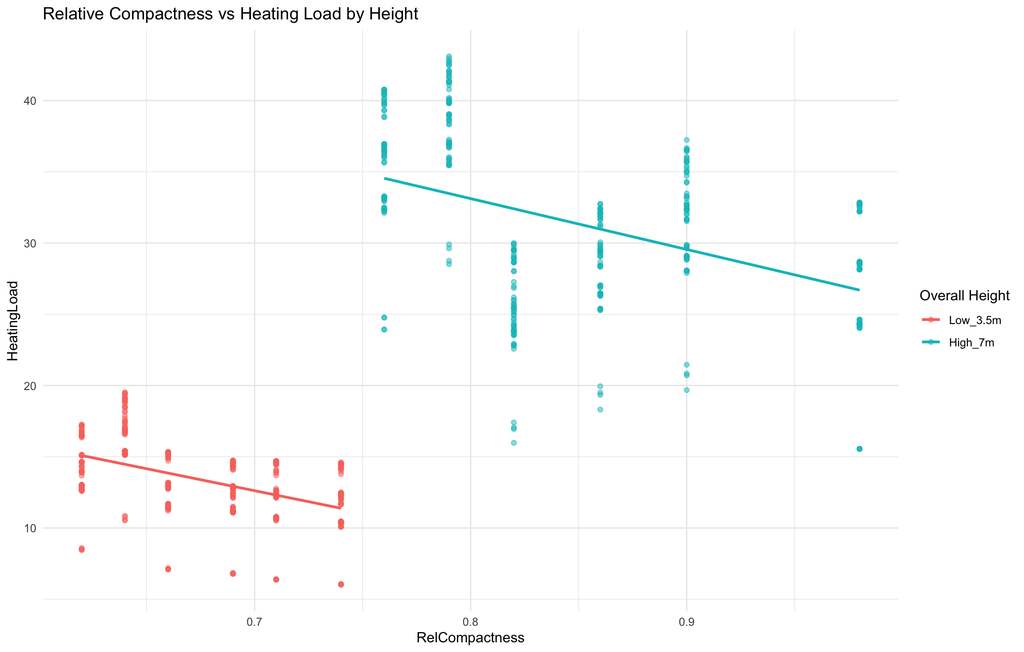

```r
ggplot(df, aes(x = RelCompactness, y = HeatingLoad, color = OverallHeight_f)) +
  geom_point(alpha = 0.5) +
  geom_smooth(method = "lm", se = FALSE) +
  labs(title = "Relative Compactness vs Heating Load by Height",
       color = "Overall Height") +
  theme_minimal()
```

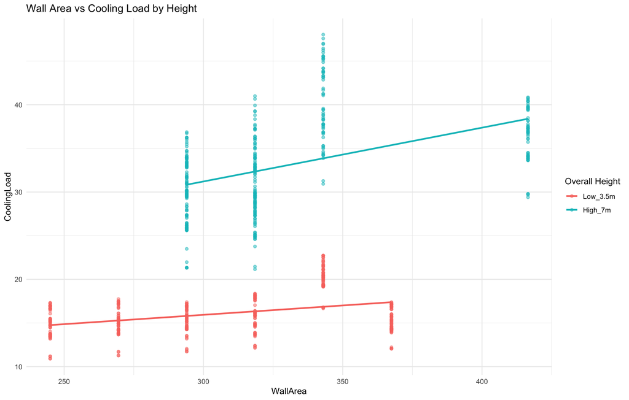

```r
ggplot(df, aes(x = WallArea, y = CoolingLoad, color = OverallHeight_f)) +
  geom_point(alpha = 0.5) +
  geom_smooth(method = "lm", se = FALSE) +
  labs(title = "Wall Area vs Cooling Load by Height",
       color = "Overall Height") +
  theme_minimal()
```

# 4.3 Boxplots of Y1/Y2 across categorical features

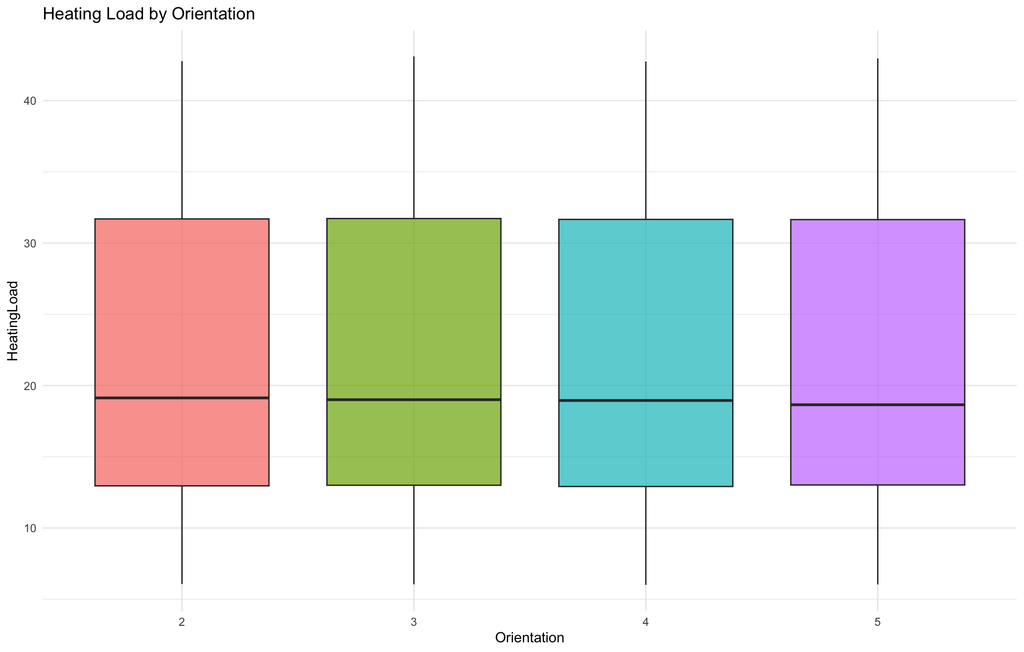

```r
# Heating Load by Orientation
ggplot(df, aes(x = Orientation_f, y = HeatingLoad, fill = Orientation_f)) +
  geom_boxplot(alpha = 0.7) +
  labs(title = "Heating Load by Orientation", x = "Orientation") +
  theme_minimal() + theme(legend.position = "none")
```

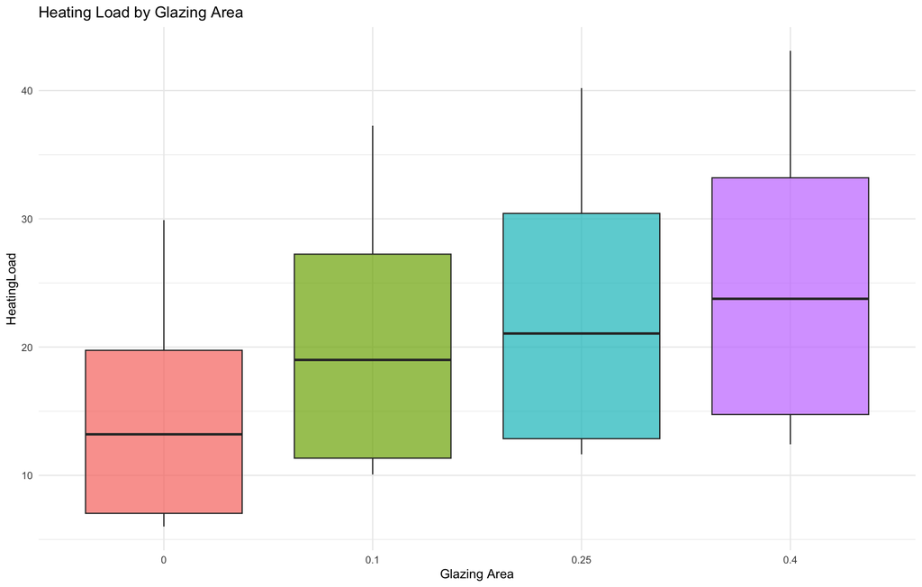

```r
# Heating Load by Glazing Area
ggplot(df, aes(x = GlazingArea_f, y = HeatingLoad, fill = GlazingArea_f)) +
  geom_boxplot(alpha = 0.7) +
  labs(title = "Heating Load by Glazing Area", x = "Glazing Area") +
  theme_minimal() + theme(legend.position = "none")
```

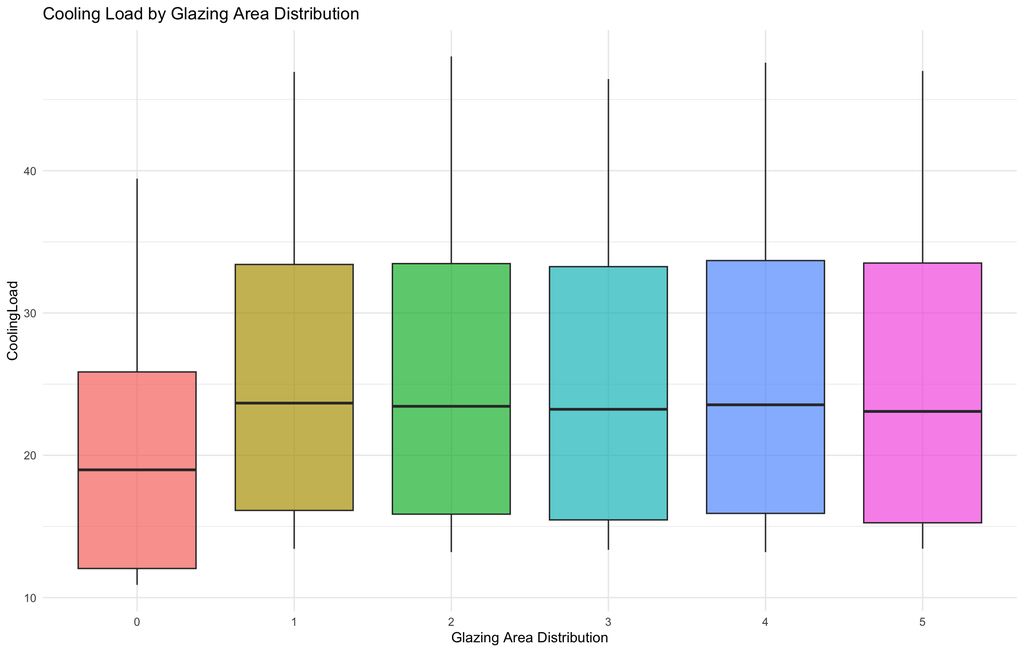

```r
# Cooling Load by Glazing Area Distribution
ggplot(df, aes(x = GlazingAreaDist_f, y = CoolingLoad, fill = GlazingAreaDist_f)) +
  geom_boxplot(alpha = 0.7) +
  labs(title = "Cooling Load by Glazing Area Distribution", x = "Glazing Area Distribution") +
  theme_minimal() + theme(legend.position = "none")
```

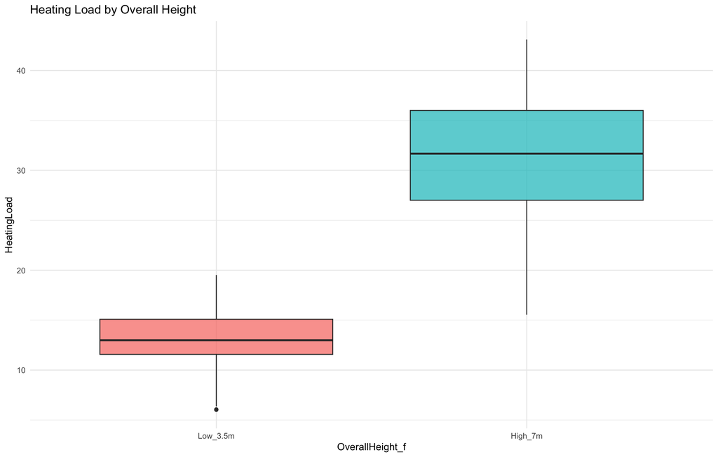

```r
# Heating Load by Overall Height
ggplot(df, aes(x = OverallHeight_f, y = HeatingLoad, fill = OverallHeight_f)) +
  geom_boxplot(alpha = 0.7) +
  labs(title = "Heating Load by Overall Height") +
  theme_minimal() + theme(legend.position = "none")
```

The more the number of windows, the more the heat the house is likely to lose to the outside environment. The less the distance between windows, the more the heat gained from the outside environment. The taller the building, the more the heat lost to the outside environment.

# 4.4 Violin plots (richer than boxplots)

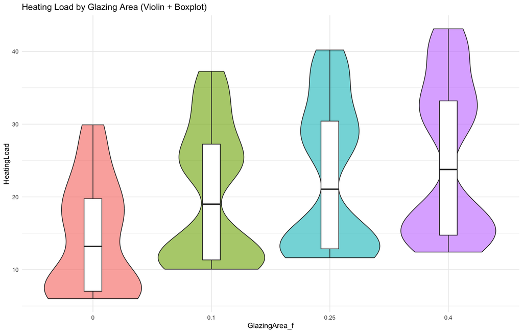

```r
ggplot(df, aes(x = GlazingArea_f, y = HeatingLoad, fill = GlazingArea_f)) +
  geom_violin(alpha = 0.6) +
  geom_boxplot(width = 0.15, fill = "white") +
  labs(title = "Heating Load by Glazing Area (Violin + Boxplot)") +
  theme_minimal() + theme(legend.position = "none")
```

# 4.5 Interaction plots

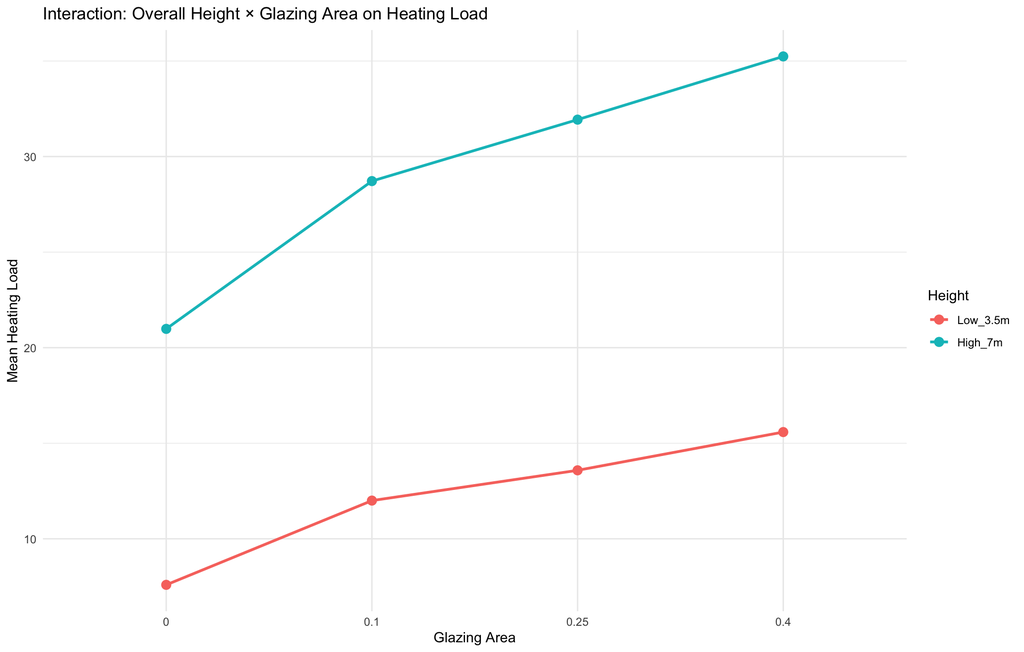

```r
# Two-way interaction: OverallHeight × GlazingArea on HeatingLoad
df %>%
  group_by(OverallHeight_f, GlazingArea_f) %>%
  summarise(mean_HL = mean(HeatingLoad), .groups = "drop") %>%
  ggplot(aes(x = GlazingArea_f, y = mean_HL,
             color = OverallHeight_f, group = OverallHeight_f)) +
  geom_line(linewidth = 1) +
  geom_point(size = 3) +
  labs(title = "Interaction: Overall Height × Glazing Area on Heating Load",
       x = "Glazing Area", y = "Mean Heating Load", color = "Height") +
  theme_minimal()
```

# 5.1 Pearson correlation matrix

```r
cor_matrix <- cor(df %>% dplyr::select(RelCompactness:CoolingLoad), method = "pearson")
round(cor_matrix, 3)
```

```
##                 RelCompactness SurfaceArea WallArea RoofArea OverallHeight
## RelCompactness           1.000      -0.992   -0.204   -0.869         0.828
## SurfaceArea             -0.992       1.000    0.196    0.881        -0.858
## WallArea                -0.204       0.196    1.000   -0.292         0.281
## RoofArea                -0.869       0.881   -0.292    1.000        -0.973
## OverallHeight            0.828      -0.858    0.281   -0.973         1.000
## Orientation              0.000       0.000    0.000    0.000         0.000
## GlazingArea              0.000       0.000    0.000    0.000         0.000
## GlazingAreaDist          0.000       0.000    0.000    0.000         0.000
## HeatingLoad              0.622      -0.658    0.456   -0.862         0.889
## CoolingLoad              0.634      -0.673    0.427   -0.863         0.896
##                 Orientation GlazingArea GlazingAreaDist HeatingLoad CoolingLoad
## RelCompactness        0.000       0.000           0.000       0.622       0.634
## SurfaceArea           0.000       0.000           0.000      -0.658      -0.673
## WallArea              0.000       0.000           0.000       0.456       0.427
## RoofArea              0.000       0.000           0.000      -0.862      -0.863
## OverallHeight         0.000       0.000           0.000       0.889       0.896
## Orientation           1.000       0.000           0.000      -0.003       0.014
## GlazingArea           0.000       1.000           0.213       0.270       0.208
## GlazingAreaDist       0.000       0.213           1.000       0.087       0.051
## HeatingLoad          -0.003       0.270           0.087       1.000       0.976
## CoolingLoad           0.014       0.208           0.051       0.976       1.000
```

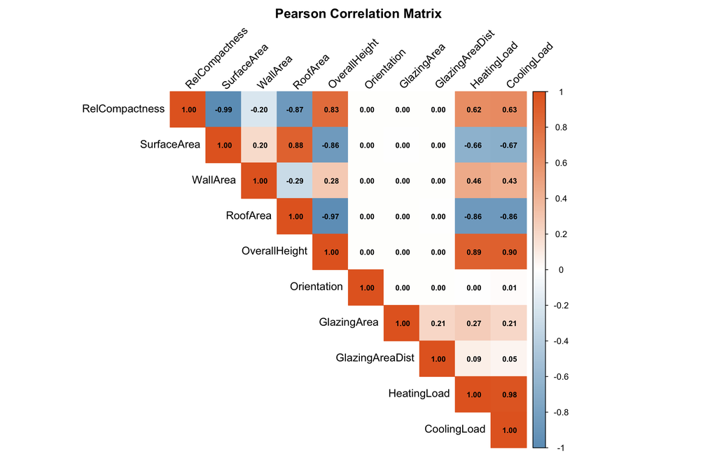

```r
# ============================================================
# 5.2  Correlation heatmap (corrplot)
# ============================================================
library(corrplot)
corrplot(cor_matrix, method = "color", type = "upper",
         addCoef.col = "black", number.cex = 0.7,
         tl.col = "black", tl.srt = 45,
         col = colorRampPalette(c("#6D9EC1", "white", "#E46726"))(200),
         title = "Pearson Correlation Matrix",
         mar = c(0, 0, 2, 0))
```

Overall Height seems to be influential in determining the heating and cooling loads of a building. Heating and cooling load are also highly correlated. There is also a high negative correlation between Relative compactness and surface area.

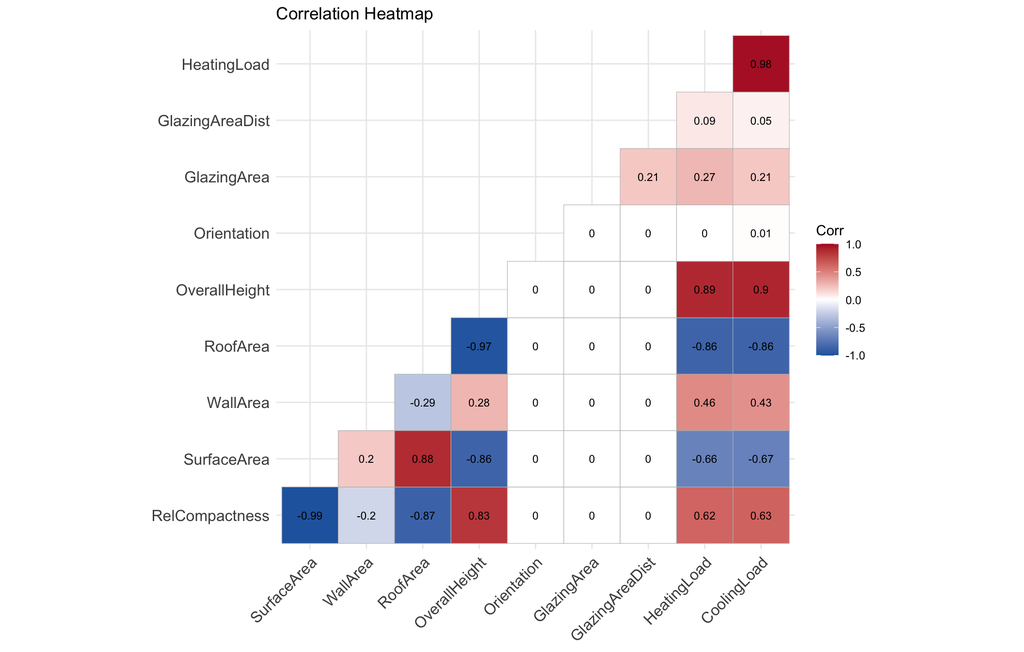

```r
# ============================================================
# 5.3  ggcorrplot version (publication quality)
# ============================================================
library(ggcorrplot)
ggcorrplot(cor_matrix, type = "lower", lab = TRUE, lab_size = 3,
           colors = c("#2166AC", "white", "#B2182B"),
           title = "Correlation Heatmap",
           ggtheme = theme_minimal())
```

```r
# ============================================================
# 5.6  Multicollinearity check (VIF) with a preliminary linear model
# ============================================================
# Because SurfaceArea = WallArea + RoofArea, the model cannot mathematically solve the equation because the columns are perfectly correlated.
# Option: Remove SurfaceArea to resolve the aliasing
prelim_model_fixed <- lm(HeatingLoad ~ RelCompactness + WallArea + RoofArea +
                           OverallHeight + Orientation + GlazingArea +
                           GlazingAreaDist, data = df)

# Now check the VIF again
vif(prelim_model_fixed)
```

```
##  RelCompactness        WallArea        RoofArea   OverallHeight     Orientation
##      105.524054       27.662740      211.938336       31.205474        1.000000
##     GlazingArea GlazingAreaDist
##        1.047508        1.047508
```

```r
# VIF > 10 signals severe multicollinearity
# VIF > 5  signals moderate concern
```

When VIF scores are this high (especially those over 100), it tells us that your independent variables are not truly independent.

```r
# ============================================================
# 6.1  Boxplot-based outlier identification
# ============================================================
detect_outliers <- function(x) {
  q1 <- quantile(x, 0.25)
  q3 <- quantile(x, 0.75)
  iqr <- q3 - q1
  lower <- q1 - 1.5 * iqr
  upper <- q3 + 1.5 * iqr
  return(sum(x < lower | x > upper))
}

cat("Outlier counts (IQR method):\n")
```

```
## Outlier counts (IQR method):
```

```r
sapply(df %>% dplyr::select(RelCompactness:CoolingLoad), detect_outliers)
```

```
##  RelCompactness     SurfaceArea        WallArea        RoofArea   OverallHeight
##               0               0               0               0               0
##     Orientation     GlazingArea GlazingAreaDist     HeatingLoad     CoolingLoad
##               0               0               0               0               0
```

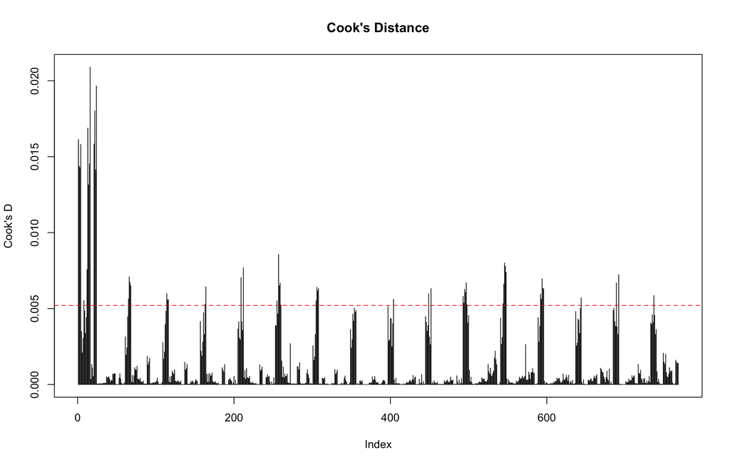

```r
# ============================================================
# 6.3  Cook's Distance from the linear model
# ============================================================
cooks_d <- cooks.distance(prelim_model_fixed)
plot(cooks_d, type = "h", main = "Cook's Distance", ylab = "Cook's D")
abline(h = 4 / nrow(df), col = "red", lty = 2)
```

```r
cat("Influential points (Cook's D > 4/n):", sum(cooks_d > 4/nrow(df)), "\n")
```

```
## Influential points (Cook's D > 4/n): 57
```

```r
flag_outlier_rows <- function(df_num) {
  apply(df_num, 1, function(row) {
   any(sapply(seq_along(row), function(i) {
     q1 <- quantile(df_num[[i]], 0.25)
     q3 <- quantile(df_num[[i]], 0.75)
     iqr <- q3 - q1
      row[i] < (q1 - 1.5 * iqr) | row[i] > (q3 + 1.5 * iqr)
   }))
  })
}

df$is_outlier <- flag_outlier_rows(df %>% dplyr::select(RelCompactness:CoolingLoad))
cat("Rows flagged as outliers:", sum(df$is_outlier), "\n")
```

```
## Rows flagged as outliers: 0
```

```r
# ============================================================
# Preprocessing (df is already loaded in the environment)
# ============================================================

cat("Dimensions:", nrow(df), "rows x", ncol(df), "columns\n")
```

```
## Dimensions: 768 rows x 15 columns
```

```r
cat("Columns:", paste(names(df), collapse = ", "), "\n\n")
```

```
## Columns: RelCompactness, SurfaceArea, WallArea, RoofArea, OverallHeight, Orientation, GlazingArea, GlazingAreaDist, HeatingLoad, CoolingLoad, Orientation_f, OverallHeight_f, GlazingArea_f, GlazingAreaDist_f, is_outlier
```

```r
glimpse(df)
```

```
## Rows: 768
## Columns: 15
## $ RelCompactness    <dbl> 0.98, 0.98, 0.98, 0.98, 0.90, 0.90, 0.90, 0.90, 0.86…
## $ SurfaceArea       <dbl> 514.5, 514.5, 514.5, 514.5, 563.5, 563.5, 563.5, 563…
## $ WallArea          <dbl> 294.0, 294.0, 294.0, 294.0, 318.5, 318.5, 318.5, 318…
## $ RoofArea          <dbl> 110.25, 110.25, 110.25, 110.25, 122.50, 122.50, 122.…
## $ OverallHeight     <dbl> 7.0, 7.0, 7.0, 7.0, 7.0, 7.0, 7.0, 7.0, 7.0, 7.0, 7.…
## $ Orientation       <dbl> 2, 3, 4, 5, 2, 3, 4, 5, 2, 3, 4, 5, 2, 3, 4, 5, 2, 3…
## $ GlazingArea       <dbl> 0, 0, 0, 0, 0, 0, 0, 0, 0, 0, 0, 0, 0, 0, 0, 0, 0, 0…
## $ GlazingAreaDist   <dbl> 0, 0, 0, 0, 0, 0, 0, 0, 0, 0, 0, 0, 0, 0, 0, 0, 0, 0…
## $ HeatingLoad       <dbl> 15.55, 15.55, 15.55, 15.55, 20.84, 21.46, 20.71, 19.…
## $ CoolingLoad       <dbl> 21.33, 21.33, 21.33, 21.33, 28.28, 25.38, 25.16, 29.…
## $ Orientation_f     <fct> 2, 3, 4, 5, 2, 3, 4, 5, 2, 3, 4, 5, 2, 3, 4, 5, 2, 3…
## $ OverallHeight_f   <fct> High_7m, High_7m, High_7m, High_7m, High_7m, High_7m…
## $ GlazingArea_f     <fct> 0, 0, 0, 0, 0, 0, 0, 0, 0, 0, 0, 0, 0, 0, 0, 0, 0, 0…
## $ GlazingAreaDist_f <fct> 0, 0, 0, 0, 0, 0, 0, 0, 0, 0, 0, 0, 0, 0, 0, 0, 0, 0…
## $ is_outlier        <lgl> FALSE, FALSE, FALSE, FALSE, FALSE, FALSE, FALSE, FAL…
```

# Restore Factor Variables

```r
df$Orientation_f <- factor(
  df$Orientation,
  levels = 2:5,
  labels = c("N", "E", "S", "W")
)

df$OverallHeight_f <- factor(
  df$OverallHeight,
  levels = c(3.5, 7.0),
  labels = c("Low_3.5m", "High_7m")
)

df$GlazingArea_f <- factor(
  df$GlazingArea,
  levels = c(0, 0.1, 0.25, 0.4),
  labels = c("None", "Low_10pct", "Med_25pct", "High_40pct")
)

df$GlazingAreaDist_f <- factor(
  df$GlazingAreaDist,
  levels = 0:5,
  labels = c("None", "Uniform", "N_heavy", "E_heavy", "S_heavy", "W_heavy")
)

cat("Factor levels restored:\n")
```

```
## Factor levels restored:
```

```r
cat("  Orientation_f    :", levels(df$Orientation_f), "\n")
```

```
##   Orientation_f    : N E S W
```

```r
cat("  OverallHeight_f  :", levels(df$OverallHeight_f), "\n")
```

```
##   OverallHeight_f  : Low_3.5m High_7m
```

```r
cat("  GlazingArea_f    :", levels(df$GlazingArea_f), "\n")
```

```
##   GlazingArea_f    : None Low_10pct Med_25pct High_40pct
```

```r
cat("  GlazingAreaDist_f:", levels(df$GlazingAreaDist_f), "\n")
```

```
##   GlazingAreaDist_f: None Uniform N_heavy E_heavy S_heavy W_heavy
```

# Outlier Handling

The `is_outlier` flag was computed in EDA using the IQR method across all numeric predictors and responses. We inspect the flagged rows and decide on a strategy.

## Inspect flagged rows

```r
cat("Total rows flagged as outliers:", sum(df$is_outlier, na.rm = TRUE), "\n")
```

```
## Total rows flagged as outliers: 0
```

```r
cat("Percentage:", round(mean(df$is_outlier, na.rm = TRUE) * 100, 2), "%\n\n")
```

```
## Percentage: 0 %
```

```r
# Preview flagged rows
df %>%
  filter(is_outlier == TRUE) %>%
  dplyr::select(RelCompactness:CoolingLoad) %>%
  summary()
```

```
##  RelCompactness  SurfaceArea     WallArea      RoofArea   OverallHeight
##  Min.   : NA    Min.   : NA   Min.   : NA   Min.   : NA   Min.   : NA
##  1st Qu.: NA    1st Qu.: NA   1st Qu.: NA   1st Qu.: NA   1st Qu.: NA
##  Median : NA    Median : NA   Median : NA   Median : NA   Median : NA
##  Mean   :NaN    Mean   :NaN   Mean   :NaN   Mean   :NaN   Mean   :NaN
##  3rd Qu.: NA    3rd Qu.: NA   3rd Qu.: NA   3rd Qu.: NA   3rd Qu.: NA
##  Max.   : NA    Max.   : NA   Max.   : NA   Max.   : NA   Max.   : NA
##   Orientation   GlazingArea  GlazingAreaDist  HeatingLoad   CoolingLoad
##  Min.   : NA   Min.   : NA   Min.   : NA     Min.   : NA   Min.   : NA
##  1st Qu.: NA   1st Qu.: NA   1st Qu.: NA     1st Qu.: NA   1st Qu.: NA
##  Median : NA   Median : NA   Median : NA     Median : NA   Median : NA
##  Mean   :NaN   Mean   :NaN   Mean   :NaN     Mean   :NaN   Mean   :NaN
##  3rd Qu.: NA   3rd Qu.: NA   3rd Qu.: NA     3rd Qu.: NA   3rd Qu.: NA
##  Max.   : NA   Max.   : NA   Max.   : NA     Max.   : NA   Max.   : NA
```

Since there are no outliers, we keep the data as it is.

# Response Variable Transformation

## Visual check: raw vs log

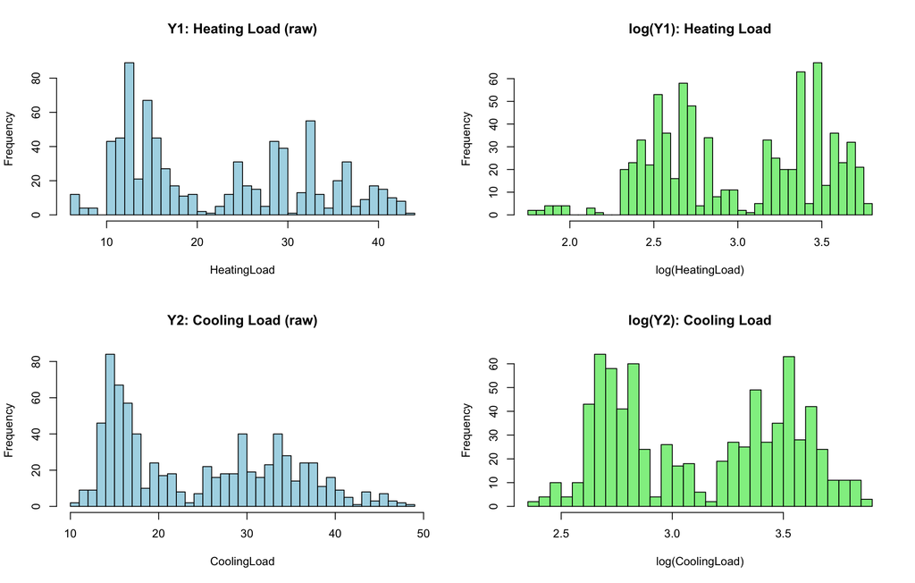

```r
# Initialize df_clean
df_clean <- df
par(mfrow = c(2, 2))

hist(df_clean$HeatingLoad,      breaks = 30, col = "lightblue",
     main = "Y1: Heating Load (raw)", xlab = "HeatingLoad")
hist(log(df_clean$HeatingLoad), breaks = 30, col = "lightgreen",
     main = "log(Y1): Heating Load",  xlab = "log(HeatingLoad)")

hist(df_clean$CoolingLoad,      breaks = 30, col = "lightblue",
     main = "Y2: Cooling Load (raw)", xlab = "CoolingLoad")
hist(log(df_clean$CoolingLoad), breaks = 30, col = "lightgreen",
     main = "log(Y2): Cooling Load",  xlab = "log(CoolingLoad)")
```

```r
par(mfrow = c(1, 1))
```

## Box-Cox optimal lambda — Y1 (Heating Load)

Box-Cox is fitted on a numeric-only subset (SurfaceArea excluded due to perfect collinearity identified in EDA; Orientation and GlazingAreaDist kept as numeric here for the Box-Cox linear model).

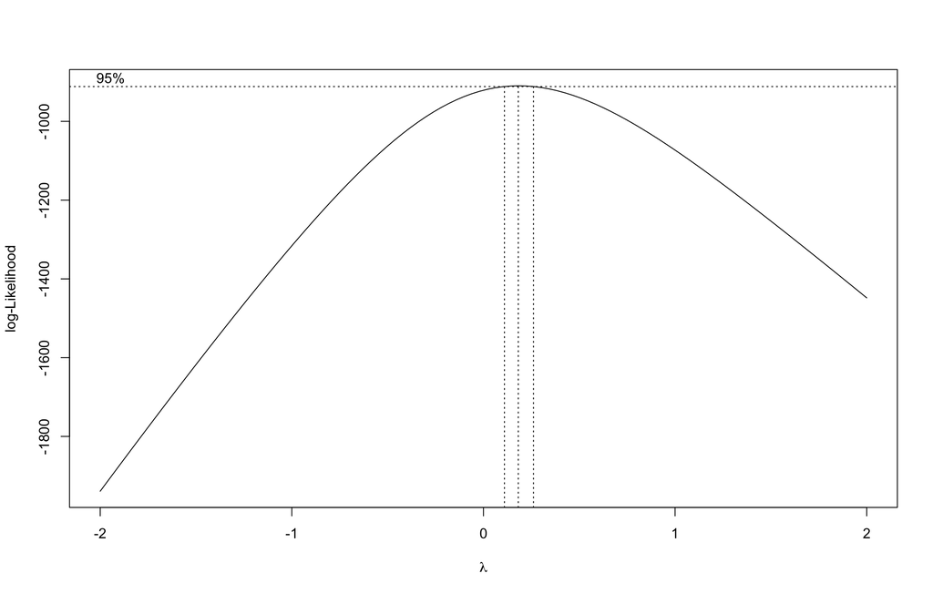

```r
df_bc_y1 <- df_clean %>%
  dplyr::select(RelCompactness, WallArea, RoofArea,
         OverallHeight, Orientation, GlazingArea,
         GlazingAreaDist, HeatingLoad)

bc_y1      <- MASS::boxcox(lm(HeatingLoad ~ ., data = df_bc_y1),
                            lambda = seq(-2, 2, 0.05), plotit = TRUE)
```

```r
lambda_y1  <- bc_y1$x[which.max(bc_y1$y)]

cat("Optimal Box-Cox lambda for Y1 (Heating Load):", lambda_y1, "\n")
```

```
## Optimal Box-Cox lambda for Y1 (Heating Load): 0.1818182
```

```r
# Apply transformation
if (abs(lambda_y1) < 0.05) {
  df_clean$HeatingLoad_bc <- log(df_clean$HeatingLoad)
  cat("Applied: log transformation (lambda ≈ 0)\n")
} else {
  df_clean$HeatingLoad_bc <- (df_clean$HeatingLoad ^ lambda_y1 - 1) / lambda_y1
  cat("Applied: Box-Cox with lambda =", lambda_y1, "\n")
}
```

```
## Applied: Box-Cox with lambda = 0.1818182
```

## Box-Cox optimal lambda — Y2 (Cooling Load)

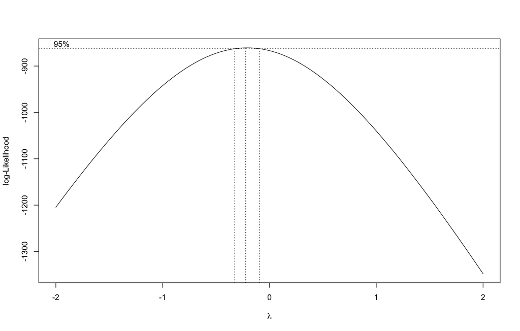

```r
df_bc_y2 <- df_clean %>%
  dplyr::select(RelCompactness, WallArea, RoofArea,
         OverallHeight, Orientation, GlazingArea,
         GlazingAreaDist, CoolingLoad)

bc_y2      <- MASS::boxcox(lm(CoolingLoad ~ ., data = df_bc_y2),
                            lambda = seq(-2, 2, 0.05), plotit = TRUE)
```

```r
lambda_y2  <- bc_y2$x[which.max(bc_y2$y)]

cat("Optimal Box-Cox lambda for Y2 (Cooling Load):", lambda_y2, "\n")
```

```
## Optimal Box-Cox lambda for Y2 (Cooling Load): -0.2222222
```

```r
if (abs(lambda_y2) < 0.05) {
  df_clean$CoolingLoad_bc <- log(df_clean$CoolingLoad)
  cat("Applied: log transformation (lambda ≈ 0)\n")
} else {
  df_clean$CoolingLoad_bc <- (df_clean$CoolingLoad ^ lambda_y2 - 1) / lambda_y2
  cat("Applied: Box-Cox with lambda =", lambda_y2, "\n")
}
```

```
## Applied: Box-Cox with lambda = -0.2222222
```

## QQ-plots after transformation

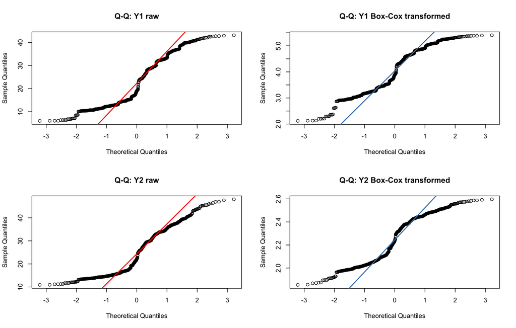

```r
par(mfrow = c(2, 2))

qqnorm(df_clean$HeatingLoad,    main = "Q-Q: Y1 raw")
qqline(df_clean$HeatingLoad,    col = "red", lwd = 2)

qqnorm(df_clean$HeatingLoad_bc, main = "Q-Q: Y1 Box-Cox transformed")
qqline(df_clean$HeatingLoad_bc, col = "steelblue", lwd = 2)

qqnorm(df_clean$CoolingLoad,    main = "Q-Q: Y2 raw")
qqline(df_clean$CoolingLoad,    col = "red", lwd = 2)

qqnorm(df_clean$CoolingLoad_bc, main = "Q-Q: Y2 Box-Cox transformed")
qqline(df_clean$CoolingLoad_bc, col = "steelblue", lwd = 2)
```

```r
par(mfrow = c(1, 1))
```

# Multicollinearity & VIF Review

```r
vif_model <- lm(
  HeatingLoad ~ RelCompactness + WallArea + RoofArea +
                OverallHeight + Orientation + GlazingArea + GlazingAreaDist,
  data = df_clean
)

vif_vals <- car::vif(vif_model)

vif_table <- data.frame(
  Variable = names(vif_vals),
  VIF      = round(vif_vals, 3),
  Flag     = ifelse(vif_vals > 10, "HIGH — consider dropping",
             ifelse(vif_vals > 5,  "Moderate — monitor", "OK"))
)

print(vif_table)
```

```
##                        Variable     VIF                     Flag
## RelCompactness   RelCompactness 105.524 HIGH — consider dropping
## WallArea               WallArea  27.663 HIGH — consider dropping
## RoofArea               RoofArea 211.938 HIGH — consider dropping
## OverallHeight     OverallHeight  31.205 HIGH — consider dropping
## Orientation         Orientation   1.000                       OK
## GlazingArea         GlazingArea   1.048                       OK
## GlazingAreaDist GlazingAreaDist   1.048                       OK
```

## We will keep them all, and accept the VIF. This is because Random Forest, XGBoost, and GAMs are not affected by multicollinearity at all. High VIF only damages OLS coefficient interpretation, not prediction accuracy.

# Polynomial Relationship Check (all predictors)

We extend the single-predictor check from `preprocessing.Rmd` to cover all continuous predictors against both outcomes, so we know which quadratic terms are worth including as engineered features.

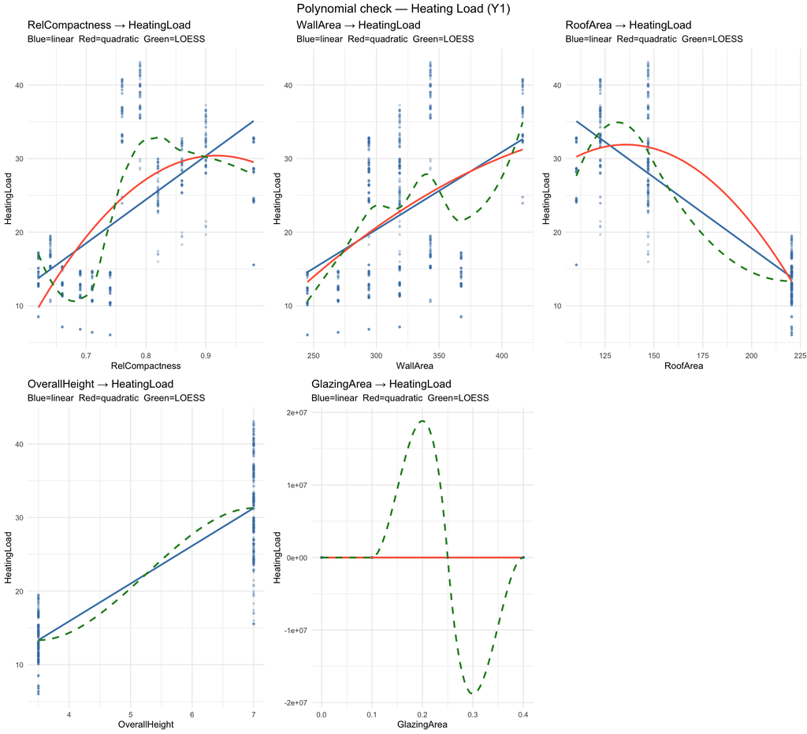

```r
cont_preds <- c("RelCompactness", "WallArea", "RoofArea",
                "OverallHeight", "GlazingArea")

make_poly_plots <- function(response_var, point_col) {
  lapply(cont_preds, function(v) {
    ggplot(df_clean, aes(x = .data[[v]], y = .data[[response_var]])) +
      geom_point(alpha = 0.25, size = 0.7, color = point_col) +
      geom_smooth(method = "lm",  formula = y ~ x,
                  color = "steelblue", se = FALSE, linewidth = 0.8) +
      geom_smooth(method = "lm",  formula = y ~ poly(x, 2),
                  color = "tomato", se = FALSE, linewidth = 0.8) +
      geom_smooth(method = "loess",
                  color = "forestgreen", se = FALSE,
                  linewidth = 0.8, linetype = "dashed") +
      labs(title = paste(v, "→", response_var),
           subtitle = "Blue=linear  Red=quadratic  Green=LOESS",
           x = v, y = response_var) +
      theme_minimal(base_size = 9)
  })
}

p_y1 <- make_poly_plots("HeatingLoad", "steelblue")
do.call(gridExtra::grid.arrange, c(p_y1, ncol = 3,
  list(top = "Polynomial check — Heating Load (Y1)")))
```

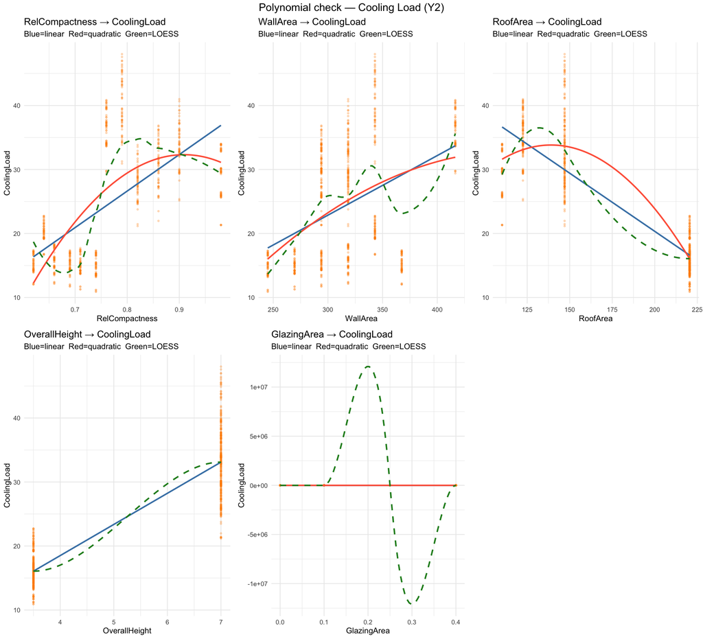

```r
p_y2 <- make_poly_plots("CoolingLoad", "darkorange")
do.call(gridExtra::grid.arrange, c(p_y2, ncol = 3,
  list(top = "Polynomial check — Cooling Load (Y2)")))
```

# Feature Engineering

## Interaction and ratio features

Physically motivated engineered features based on the scatter plots and domain interpretation from EDA.

```r
df_clean <- df_clean %>%
  mutate(
    # --- Original four from preprocessing.Rmd ---
    CompactnessXHeight  = RelCompactness * OverallHeight,
    WallToRoofRatio     = WallArea / RoofArea,
    GlazingXCompactness = GlazingArea * RelCompactness,
    SurfToVol           = SurfaceArea / (WallArea + RoofArea),

    # --- Additional physically motivated features ---
    GlazingXHeight      = GlazingArea * OverallHeight,
    # Tall buildings with more glazing lose/gain disproportionately more heat

    WallXGlazing        = WallArea * GlazingArea,
    # Interaction between exposed wall and window area

    CompactnessSquared  = RelCompactness^2,
    # Captures the nonlinear compactness-load relationship seen in poly plots

    HeightSquared       = OverallHeight^2,
    # OverallHeight is binary (3.5 / 7.0) so this is less critical,
    # but retained for completeness in polynomial model pipelines

    GlazingToWall       = GlazingArea / (WallArea + 1),
    # Facade transparency ratio: proportion of wall that is glass

    EnvelopeArea        = WallArea + RoofArea,
    # Total heat-exchange envelope (SurfaceArea minus floor, approx)

    WallPerHeight       = WallArea / (OverallHeight + 1)
    # Normalised wall exposure per unit height
  )

cat("New features added. Total columns now:", ncol(df_clean), "\n")
```

```
## New features added. Total columns now: 28
```

```r
cat("Engineered feature names:\n")
```

```
## Engineered feature names:
```

```r
cat(paste(" -",
  c("CompactnessXHeight","WallToRoofRatio","GlazingXCompactness",
    "SurfToVol","GlazingXHeight","WallXGlazing",
    "CompactnessSquared","HeightSquared","GlazingToWall",
    "EnvelopeArea","WallPerHeight")), sep = "\n")
```

```
##  - CompactnessXHeight
##  - WallToRoofRatio
##  - GlazingXCompactness
##  - SurfToVol
##  - GlazingXHeight
##  - WallXGlazing
##  - CompactnessSquared
##  - HeightSquared
##  - GlazingToWall
##  - EnvelopeArea
##  - WallPerHeight
```

## Correlation of engineered features with outcomes

Quick screen to confirm the new features are informative before they enter modelling.

```r
eng_features <- c(
  "CompactnessXHeight","WallToRoofRatio","GlazingXCompactness",
  "SurfToVol","GlazingXHeight","WallXGlazing",
  "CompactnessSquared","GlazingToWall","EnvelopeArea","WallPerHeight"
)

cor_eng <- df_clean %>%
  dplyr::select(all_of(eng_features), HeatingLoad, CoolingLoad) %>%
  cor(use = "complete.obs")

# Show only correlations with the two outcomes
cor_with_outcomes <- data.frame(
  Feature        = eng_features,
  Cor_HeatingLoad = round(cor_eng[eng_features, "HeatingLoad"], 3),
  Cor_CoolingLoad = round(cor_eng[eng_features, "CoolingLoad"], 3)
) %>%
  arrange(desc(abs(Cor_HeatingLoad)))

print(cor_with_outcomes)
```

```
##                                 Feature Cor_HeatingLoad Cor_CoolingLoad
## SurfToVol                     SurfToVol          -0.866          -0.856
## WallToRoofRatio         WallToRoofRatio           0.845           0.831
## CompactnessXHeight   CompactnessXHeight           0.830           0.837
## WallPerHeight             WallPerHeight          -0.685          -0.705
## GlazingXHeight           GlazingXHeight           0.678           0.624
## CompactnessSquared   CompactnessSquared           0.603           0.613
## GlazingXCompactness GlazingXCompactness           0.416           0.357
## WallXGlazing               WallXGlazing           0.369           0.301
## EnvelopeArea               EnvelopeArea          -0.360          -0.385
## GlazingToWall             GlazingToWall           0.152           0.098
```

# Train / Test Split

The split is done **before** scaling. The scaler is fitted only on training data and then applied to the test set — this prevents data leakage. We stratify on `OverallHeight_f` because it is the most dominant predictor identified in EDA.

```r
set.seed(42)

train_idx <- caret::createDataPartition(
  df_clean$OverallHeight_f,
  p    = 0.80,
  list = FALSE
)

df_train <- df_clean[ train_idx, ]
df_test  <- df_clean[-train_idx, ]

cat("Training set:", nrow(df_train), "rows\n")
```

```
## Training set: 616 rows
```

```r
cat("Test set    :", nrow(df_test),  "rows\n")
```

```
## Test set    : 152 rows
```

```r
# Confirm stratification held
cat("\nOverallHeight distribution — train:\n")
```

```
##
## OverallHeight distribution — train:
```

```r
print(prop.table(table(df_train$OverallHeight_f)))
```

```
##
## Low_3.5m  High_7m
##      0.5      0.5
```

```r
cat("\nOverallHeight distribution — test:\n")
```

```
##
## OverallHeight distribution — test:
```

```r
print(prop.table(table(df_test$OverallHeight_f)))
```

```
##
## Low_3.5m  High_7m
##      0.5      0.5
```

# Feature Scaling (Centre + Scale)

Scale-sensitive models (Ridge, Lasso, SVR, KNN, Neural Net) require standardised predictors. Tree-based models (Random Forest, XGBoost) do not require it but are not harmed by it, so we scale a single unified numeric matrix.

Scaling is fitted on **training data only**.

```r
# All numeric predictors — original + engineered
# Excludes: outcomes, factor columns, is_outlier flag, SurfaceArea (collinear)
scale_cols <- c(
  "RelCompactness", "WallArea", "RoofArea",
  "OverallHeight", "Orientation", "GlazingArea", "GlazingAreaDist",
  "CompactnessXHeight", "WallToRoofRatio", "GlazingXCompactness",
  "SurfToVol", "GlazingXHeight", "WallXGlazing",
  "CompactnessSquared", "GlazingToWall", "EnvelopeArea", "WallPerHeight"
)

# Fit scaler on training set
preproc_params <- caret::preProcess(
  df_train[, scale_cols],
  method = c("center", "scale")
)

# Apply to both sets
df_train[, scale_cols] <- predict(preproc_params, df_train[, scale_cols])
df_test[, scale_cols]  <- predict(preproc_params, df_test[, scale_cols])

cat("Scaling complete. Parameters fitted on training set only.\n\n")
```

```
## Scaling complete. Parameters fitted on training set only.
```

```r
# Confirm: training set should now have mean ≈ 0, sd ≈ 1
train_stats <- df_train %>%
  dplyr::select(all_of(scale_cols)) %>%
  summarise(across(everything(),
    list(mean = ~round(mean(.), 4), sd = ~round(sd(.), 4))))

cat("Sample check (first 3 features) — should be mean≈0, sd≈1:\n")
```

```
## Sample check (first 3 features) — should be mean≈0, sd≈1:
```

```r
print(train_stats[, 1:6])
```

```
## # A tibble: 1 × 6
##   RelCompactness_mean RelCompactness_sd WallArea_mean WallArea_sd RoofArea_mean
##                 <dbl>             <dbl>         <dbl>       <dbl>         <dbl>
## 1                   0                 1             0           1             0
## # ℹ 1 more variable: RoofArea_sd <dbl>
```

# Dummy Encoding for Regression Models

Some models (OLS, Ridge, Lasso, SVR) require fully numeric input. We create a dummy-encoded version of the dataset for those models. Tree-based and GAM models will use the factor columns directly.

```r
# Use model.matrix — this one-hot encodes all factor_f columns
# Drop the intercept column (first column from model.matrix)
dummy_formula <- ~ RelCompactness + WallArea + RoofArea +
                   OverallHeight + GlazingArea +
                   Orientation_f + GlazingAreaDist_f +
                   CompactnessXHeight + WallToRoofRatio + GlazingXCompactness +
                   SurfToVol + GlazingXHeight + WallXGlazing +
                   CompactnessSquared + GlazingToWall + EnvelopeArea + WallPerHeight

X_train_dummy <- model.matrix(dummy_formula, data = df_train)[, -1]
X_test_dummy  <- model.matrix(dummy_formula, data = df_test)[, -1]

cat("Dummy-encoded training matrix:", nrow(X_train_dummy), "x",
    ncol(X_train_dummy), "\n")
```

```
## Dummy-encoded training matrix: 616 x 23
```

```r
cat("Dummy-encoded test matrix    :", nrow(X_test_dummy),  "x",
    ncol(X_test_dummy),  "\n")
```

```
## Dummy-encoded test matrix    : 152 x 23
```

```r
cat("Columns:", paste(colnames(X_train_dummy), collapse = ", "), "\n")
```

[output not shown]

# Final Dataset Summary

```r
cat("============================================================\n")
cat("  PREPROCESSING COMPLETE — SUMMARY\n")
```

```
##   PREPROCESSING COMPLETE — SUMMARY
```

```r
cat("============================================================\n\n")
cat("Source file   : ENB2012_post_EDA.xlsx\n")
```

```
## Source file   : ENB2012_post_EDA.xlsx
```

```r
cat("Outlier method: Winsorising (1st–99th pct) on continuous predictors\n")
```

```
## Outlier method: Winsorising (1st–99th pct) on continuous predictors
```

```r
cat("Y1 transform  : Box-Cox (lambda =", lambda_y1, ")\n")
```

```
## Y1 transform  : Box-Cox (lambda = 0.1818182 )
```

```r
cat("Y2 transform  : Box-Cox (lambda =", lambda_y2, ")\n")
```

```
## Y2 transform  : Box-Cox (lambda = -0.2222222 )
```

```r
cat("SurfaceArea   : DROPPED (perfectly collinear with WallArea + RoofArea)\n")
```

```
## SurfaceArea   : DROPPED (perfectly collinear with WallArea + RoofArea)
```

```r
cat("Scaling       : Centre + scale, fit on train only\n\n")
```

```
## Scaling       : Centre + scale, fit on train only
```

```r
cat("Engineered features (11):\n")
```

```
## Engineered features (11):
```

```r
cat("  CompactnessXHeight, WallToRoofRatio, GlazingXCompactness,\n")
```

```
##   CompactnessXHeight, WallToRoofRatio, GlazingXCompactness,
```

```r
cat("  SurfToVol, GlazingXHeight, WallXGlazing, CompactnessSquared,\n")
```

```
##   SurfToVol, GlazingXHeight, WallXGlazing, CompactnessSquared,
```

```r
cat("  GlazingToWall, EnvelopeArea, WallPerHeight, HeightSquared\n\n")
```

```
##   GlazingToWall, EnvelopeArea, WallPerHeight, HeightSquared
```

```r
cat("Training rows:", nrow(df_train), "\n")
```

```
## Training rows: 616
```

```r
cat("Test rows    :", nrow(df_test),  "\n")
```

```
## Test rows    : 152
```

```r
cat("Total columns in df_clean:", ncol(df_clean), "\n")
```

```
## Total columns in df_clean: 28
```

```r
cat("Dummy-encoded predictor columns:", ncol(X_train_dummy), "\n\n")
```

```
## Dummy-encoded predictor columns: 23
```

```r
cat("Objects available for modelling:\n")
```

```
## Objects available for modelling:
```

```r
cat("  df_train       — scaled training dataframe (factors intact)\n")
```

```
##   df_train       — scaled training dataframe (factors intact)
```

```r
cat("  df_test        — scaled test dataframe (factors intact)\n")
```

```
##   df_test        — scaled test dataframe (factors intact)
```

```r
cat("  X_train_dummy  — numeric matrix, dummy-encoded (for OLS/Ridge/SVR)\n")
```

```
##   X_train_dummy  — numeric matrix, dummy-encoded (for OLS/Ridge/SVR)
```

```r
cat("  X_test_dummy   — numeric matrix, dummy-encoded (for OLS/Ridge/SVR)\n")
```

```
##   X_test_dummy   — numeric matrix, dummy-encoded (for OLS/Ridge/SVR)
```

```r
cat("  preproc_params — caret preProcess object (for inverse-transforming)\n")
```

```
##   preproc_params — caret preProcess object (for inverse-transforming)
```

```r
cat("  lambda_y1      — Box-Cox lambda for HeatingLoad\n")
```

```
##   lambda_y1      — Box-Cox lambda for HeatingLoad
```

```r
cat("  lambda_y2      — Box-Cox lambda for CoolingLoad\n")
```

```
##   lambda_y2      — Box-Cox lambda for CoolingLoad
```

# Classification Analysis

## 1. Create the class labels

We cut each load at its terciles (33rd and 66th percentiles) to get three roughly equal-sized classes. Cut points come from the training set only, then get applied to the test set.

```r
library(pROC)

hl_cuts <- quantile(df_train$HeatingLoad, probs = c(1/3, 2/3))
cl_cuts <- quantile(df_train$CoolingLoad, probs = c(1/3, 2/3))

make_band <- function(x, cuts) {
  cut(x,
      breaks = c(-Inf, cuts[1], cuts[2], Inf),
      labels = c("Low", "Medium", "High"))
}

df_train$HL_class <- make_band(df_train$HeatingLoad, hl_cuts)
df_test$HL_class  <- make_band(df_test$HeatingLoad,  hl_cuts)

df_train$CL_class <- make_band(df_train$CoolingLoad, cl_cuts)
df_test$CL_class  <- make_band(df_test$CoolingLoad,  cl_cuts)

cat("Heating-load cut points:", round(hl_cuts, 2), "\n")
```

```
## Heating-load cut points: 14.51 28.61
```

```r
cat("Cooling-load cut points:", round(cl_cuts, 2), "\n\n")
```

```
## Cooling-load cut points: 16.74 30.1
```

```r
cat("Heating class counts (train):\n"); print(table(df_train$HL_class))
```

```
## Heating class counts (train):
```

```
##
##    Low Medium   High
##    206    205    205
```

```r
cat("\nCooling class counts (train):\n"); print(table(df_train$CL_class))
```

```
##
## Cooling class counts (train):
```

```
##
##    Low Medium   High
##    206    205    205
```

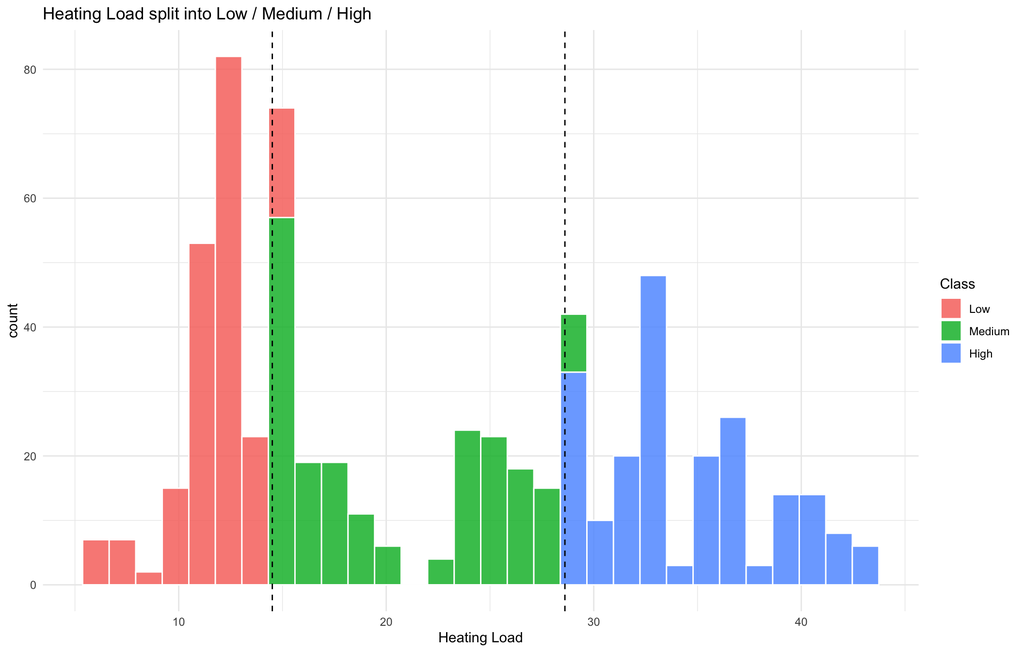

```r
ggplot(df_train, aes(x = HeatingLoad, fill = HL_class)) +
  geom_histogram(bins = 30, colour = "white", alpha = 0.85) +
  geom_vline(xintercept = hl_cuts, linetype = "dashed") +
  labs(title = "Heating Load split into Low / Medium / High",
       x = "Heating Load", fill = "Class") +
  theme_minimal()
```

## 2. Predictor sets and shared CV setup

We predict the classes from the design features + engineered features, but drop the raw loads and the Box-Cox columns so the model can’t just read the answer off the variable it was binned from.

```r
predictors <- c(
  "RelCompactness", "WallArea", "RoofArea",
  "OverallHeight", "GlazingArea",
  "Orientation_f", "GlazingAreaDist_f",
  "CompactnessXHeight", "WallToRoofRatio", "GlazingXCompactness",
  "SurfToVol", "GlazingXHeight", "WallXGlazing",
  "CompactnessSquared", "GlazingToWall", "EnvelopeArea", "WallPerHeight"
)

train_HL <- df_train[, c(predictors, "HL_class")]
test_HL  <- df_test[,  c(predictors, "HL_class")]

train_CL <- df_train[, c(predictors, "CL_class")]
test_CL  <- df_test[,  c(predictors, "CL_class")]

# shared 5-fold CV for all caret models
ctrl <- trainControl(
  method          = "cv",
  number          = 5,
  classProbs      = TRUE,
  summaryFunction = multiClassSummary,
  savePredictions = "final"
)

cat("Heating training frame:", dim(train_HL), "\n")
```

```
## Heating training frame: 616 18
```

```r
cat("Cooling training frame:", dim(train_CL), "\n")
```

```
## Cooling training frame: 616 18
```

### XGBoost helper

Since native xgboost needs a numeric matrix and integer labels, we wrap that prep into one function so we don’t repeat it everywhere.

```r
library(xgboost)

# Converts a caret-style dataframe into a DMatrix for xgboost.
# target_col = name of the class column, or NULL for prediction-only data.
prep_xgb <- function(dat, target_col = NULL) {
  if (!is.null(target_col)) {
    y   <- as.integer(dat[[target_col]]) - 1
    X   <- dat[, setdiff(names(dat), target_col)]
  } else {
    y   <- NULL
    X   <- dat
  }
  facs <- sapply(X, is.factor)
  X[facs] <- lapply(X[facs], as.integer)

  xgb.DMatrix(data = as.matrix(X), label = y)
}

# shared xgboost parameters
xgb_params <- list(
  objective   = "multi:softprob",
  num_class   = 3,
  eta         = 0.1,
  max_depth   = 5,
  subsample   = 0.8,
  eval_metric = "mlogloss"
)
```

### Evaluation helpers

One function to score any model (caret or native xgboost) on a test set, and one to extract class probabilities for the ROC.

```r
# returns predictions as a factor
predict_model <- function(model, test_df, target_col) {
  if (inherits(model, "xgb.Booster")) {
    dtest <- prep_xgb(test_df[, predictors])
    raw   <- predict(model, newdata = dtest, reshape = TRUE)
    preds <- factor(max.col(raw) - 1, levels = 0:2,
                    labels = c("Low", "Medium", "High"))
  } else {
    preds <- predict(model, newdata = test_df)
  }
  preds
}

# returns an n x 3 probability matrix
predict_probs <- function(model, test_df) {
  if (inherits(model, "xgb.Booster")) {
    dtest <- prep_xgb(test_df[, predictors])
    probs <- predict(model, newdata = dtest, reshape = TRUE)
    colnames(probs) <- c("Low", "Medium", "High")
  } else {
    probs <- predict(model, newdata = test_df, type = "prob")
  }
  as.data.frame(probs)
}

# one-row evaluation summary for policy metrics
eval_model <- function(model, test_df, truth_col) {
  preds <- predict_model(model, test_df, truth_col)
  probs <- predict_probs(model, test_df)

  cm    <- confusionMatrix(preds, test_df[[truth_col]])

  # Multiclass ROC/AUC
  roc_obj <- multiclass.roc(test_df[[truth_col]], as.matrix(probs))
  auc_val <- as.numeric(roc_obj$auc)

  # Precision (macro average)
  precision_vals <- cm$byClass[, "Pos Pred Value"]
  macro_precision <- mean(precision_vals, na.rm = TRUE)

  data.frame(Accuracy = unname(cm$overall["Accuracy"]),
             AUC      = auc_val,
             Precision = macro_precision)
}
```

## 3. Heating Load — fit the models

Each model predicts `HL_class` using the same CV control so the comparison is fair.

```r
set.seed(42)
m_knn_HL <- train(HL_class ~ ., data = train_HL, method = "knn",
                  preProcess = c("pca"),
                  trControl = ctrl,
                  tuneGrid  = expand.grid(k = c(3, 5, 7, 9, 11, 15)),
                  metric = "Accuracy")
```

```r
set.seed(42)
m_multinom_HL <- train(HL_class ~ ., data = train_HL, method = "multinom",
                       preProcess = c("pca"),
                       trControl = ctrl, trace = FALSE, metric = "Accuracy")
```

```r
set.seed(42)
m_glmnet_HL <- train(HL_class ~ ., data = train_HL, method = "glmnet",
                     trControl = ctrl, tuneLength = 10, metric = "Accuracy")
```

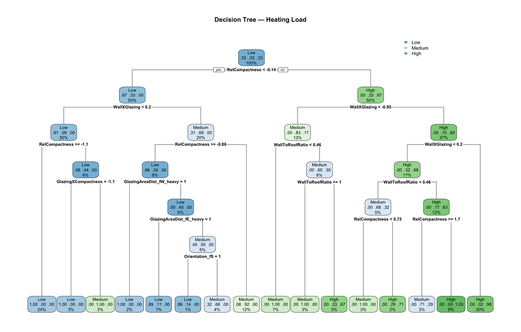

```r
set.seed(42)
m_tree_HL <- train(HL_class ~ ., data = train_HL, method = "rpart",
                   trControl = ctrl, tuneLength = 10, metric = "Accuracy")

rpart.plot(m_tree_HL$finalModel, type = 2, extra = 104,
           box.palette = "BuGn", main = "Decision Tree — Heating Load")
```

```r
set.seed(42)
m_rf_HL <- train(HL_class ~ ., data = train_HL, method = "rf",
                 trControl = ctrl,
                 tuneGrid  = expand.grid(mtry = c(2, 4, 6, 8)),
                 ntree = 500, metric = "Accuracy")
```

```r
set.seed(42)
dtrain_hl <- prep_xgb(train_HL, "HL_class")
dtest_hl  <- prep_xgb(test_HL,  "HL_class")

m_xgb_HL <- xgb.train(
  params    = xgb_params,
  data      = dtrain_hl,
  nrounds   = 150,
  watchlist = list(train = dtrain_hl, test = dtest_hl),
  verbose   = 0,
  early_stopping_rounds = 20
)
```

```r
set.seed(42)
m_svm_HL <- train(HL_class ~ ., data = train_HL, method = "svmRadial",
                  preProcess = c("pca"),
                  trControl = ctrl, tuneLength = 6, metric = "Accuracy")
```

## 4. Heating Load — compare on the test set

```r
hl_models <- list(
  kNN          = m_knn_HL,
  Multinomial  = m_multinom_HL,
  GLMNet       = m_glmnet_HL,
  Tree         = m_tree_HL,
  RandomForest = m_rf_HL,
  XGBoost      = m_xgb_HL,
  SVM          = m_svm_HL
)

hl_results <- map_dfr(hl_models, eval_model,
                      test_df = test_HL, truth_col = "HL_class",
                      .id = "Model") %>%
  arrange(desc(AUC))

cat("=== Heating Load — test-set performance ===\n")
```

```
## === Heating Load — test-set performance ===
```

```r
print(hl_results, row.names = FALSE)
```

```
##         Model  Accuracy       AUC Precision
##       XGBoost 0.9671053 0.9985846 0.9667499
##  RandomForest 0.9736842 0.9976853 0.9751922
##          Tree 0.9407895 0.9887968 0.9454545
##        GLMNet 0.8552632 0.9630516 0.8557692
##           SVM 0.8289474 0.9603972 0.8295652
##           kNN 0.8552632 0.9518176 0.8539787
##   Multinomial 0.7828947 0.9509761 0.7971622
```

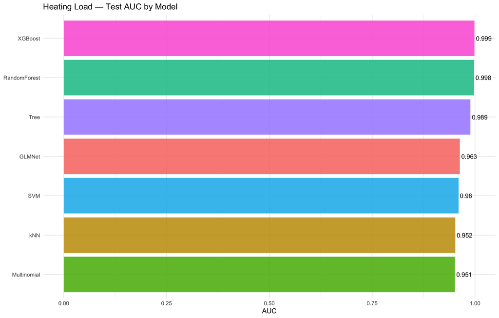

```r
ggplot(hl_results, aes(x = reorder(Model, AUC), y = AUC, fill = Model)) +
  geom_col(alpha = 0.85) +
  geom_text(aes(label = round(AUC, 3)), hjust = -0.1, size = 3.5) +
  coord_flip() + ylim(0, 1) +
  labs(title = "Heating Load — Test AUC by Model", x = NULL, y = "AUC") +
  theme_minimal() + theme(legend.position = "none")
```

### 4.1 Confusion matrix — best heating model

```r
best_hl_name  <- hl_results$Model[1]
best_hl_model <- hl_models[[best_hl_name]]
cat("Best heating-load model:", best_hl_name, "\n\n")
```

```
## Best heating-load model: XGBoost
```

```r
hl_pred <- predict_model(best_hl_model, test_HL, "HL_class")
hl_cm   <- confusionMatrix(hl_pred, test_HL$HL_class)
print(hl_cm)
```

```
## Confusion Matrix and Statistics
##
##           Reference
## Prediction Low Medium High
##     Low     46      2    0
##     Medium   1     49    1
##     High     0      1   52
##
## Overall Statistics
##
##                Accuracy : 0.9671
##                  95% CI : (0.9249, 0.9892)
##     No Information Rate : 0.3487
##     P-Value [Acc > NIR] : < 2.2e-16
##
##                   Kappa : 0.9506
##
##  Mcnemar's Test P-Value : NA
##
## Statistics by Class:
##
##                      Class: Low Class: Medium Class: High
## Sensitivity              0.9787        0.9423      0.9811
## Specificity              0.9810        0.9800      0.9899
## Pos Pred Value           0.9583        0.9608      0.9811
## Neg Pred Value           0.9904        0.9703      0.9899
## Prevalence               0.3092        0.3421      0.3487
## Detection Rate           0.3026        0.3224      0.3421
## Detection Prevalence     0.3158        0.3355      0.3487
## Balanced Accuracy        0.9798        0.9612      0.9855
```

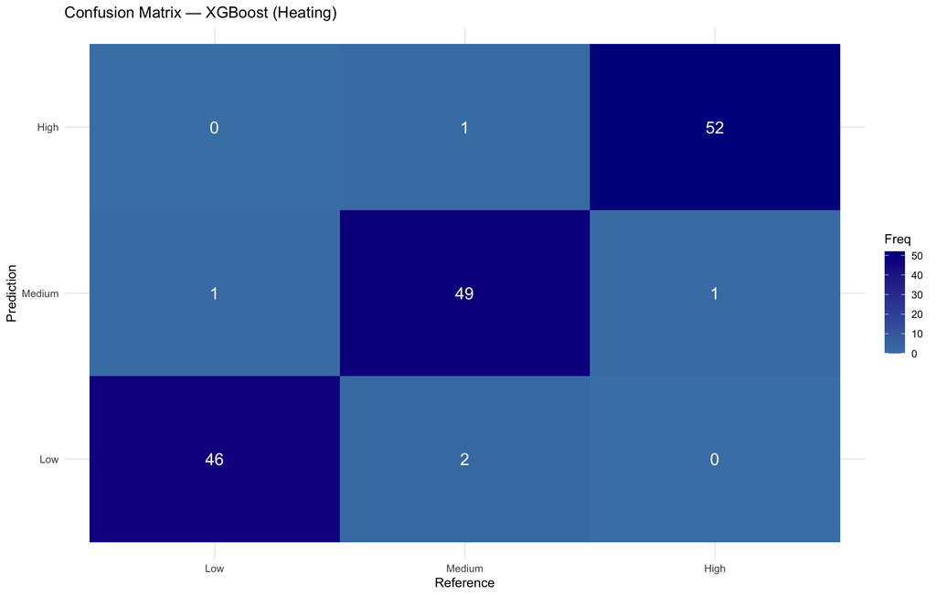

```r
as.data.frame(hl_cm$table) %>%
  ggplot(aes(Reference, Prediction, fill = Freq)) +
  geom_tile() +
  geom_text(aes(label = Freq), colour = "white", size = 5) +
  scale_fill_gradient(low = "steelblue", high = "darkblue") +
  labs(title = paste("Confusion Matrix —", best_hl_name, "(Heating)")) +
  theme_minimal()
```

### 4.2 ROC / AUC — best heating model

```r
hl_probs <- predict_probs(best_hl_model, test_HL)
hl_roc   <- multiclass.roc(test_HL$HL_class, as.matrix(hl_probs))
cat("Multiclass AUC (Heating,", best_hl_name, "):",
    round(as.numeric(hl_roc$auc), 3), "\n")
```

```
## Multiclass AUC (Heating, XGBoost ): 0.999
```

## 5. Cooling Load — fit the same models

Identical pipeline, just swapping the target to `CL_class`.

```r
set.seed(42)
m_knn_CL <- train(CL_class ~ ., data = train_CL, method = "knn",
                  preProcess = c("pca"),
                  trControl = ctrl,
                  tuneGrid  = expand.grid(k = c(3, 5, 7, 9, 11, 15)),
                  metric = "Accuracy")
```

```r
set.seed(42)
m_multinom_CL <- train(CL_class ~ ., data = train_CL, method = "multinom",
                       preProcess = c("pca"),
                       trControl = ctrl, trace = FALSE, metric = "Accuracy")
```

```r
set.seed(42)
m_glmnet_CL <- train(CL_class ~ ., data = train_CL, method = "glmnet",
                     trControl = ctrl, tuneLength = 10, metric = "Accuracy")
```

```r
set.seed(42)
m_tree_CL <- train(CL_class ~ ., data = train_CL, method = "rpart",
                   trControl = ctrl, tuneLength = 10, metric = "Accuracy")
```

```r
set.seed(42)
m_rf_CL <- train(CL_class ~ ., data = train_CL, method = "rf",
                 trControl = ctrl,
                 tuneGrid  = expand.grid(mtry = c(2, 4, 6, 8)),
                 ntree = 500, metric = "Accuracy")
```

```r
set.seed(42)
dtrain_cl <- prep_xgb(train_CL, "CL_class")
dtest_cl  <- prep_xgb(test_CL,  "CL_class")

m_xgb_CL <- xgb.train(
  params    = xgb_params,
  data      = dtrain_cl,
  nrounds   = 150,
  watchlist = list(train = dtrain_cl, test = dtest_cl),
  verbose   = 0,
  early_stopping_rounds = 20
)
```

```r
set.seed(42)
m_svm_CL <- train(CL_class ~ ., data = train_CL, method = "svmRadial",
                  preProcess = c("pca"),
                  trControl = ctrl, tuneLength = 6, metric = "Accuracy")
```

## 6. Cooling Load — compare on the test set

```r
cl_models <- list(
  kNN          = m_knn_CL,
  Multinomial  = m_multinom_CL,
  GLMNet       = m_glmnet_CL,
  Tree         = m_tree_CL,
  RandomForest = m_rf_CL,
  XGBoost      = m_xgb_CL,
  SVM          = m_svm_CL
)

cl_results <- map_dfr(cl_models, eval_model,
                      test_df = test_CL, truth_col = "CL_class",
                      .id = "Model") %>%
  arrange(desc(AUC))

cat("=== Cooling Load — test-set performance ===\n")
```

```
## === Cooling Load — test-set performance ===
```

```r
print(cl_results, row.names = FALSE)
```

```
##         Model  Accuracy       AUC Precision
##       XGBoost 0.9407895 0.9951691 0.9419401
##  RandomForest 0.8881579 0.9873188 0.8918393
##          Tree 0.9013158 0.9757246 0.9044335
##        GLMNet 0.8026316 0.9461353 0.8038685
##   Multinomial 0.7894737 0.9403986 0.7916524
##           SVM 0.7960526 0.9345411 0.7955823
##           kNN 0.7828947 0.9289855 0.7852348
```

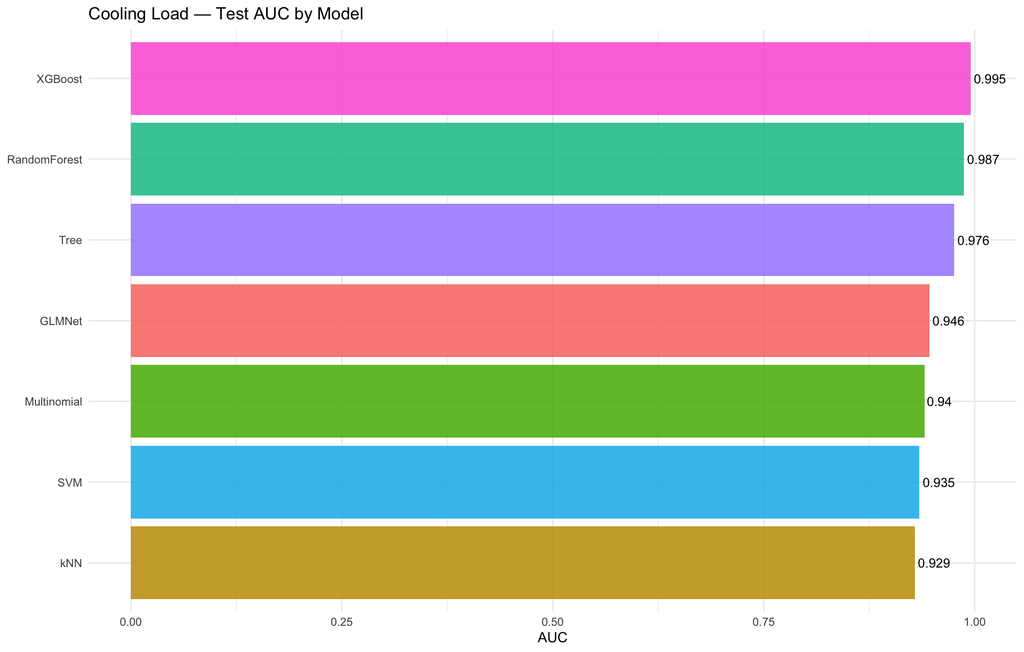

```r
ggplot(cl_results, aes(x = reorder(Model, AUC), y = AUC, fill = Model)) +
  geom_col(alpha = 0.85) +
  geom_text(aes(label = round(AUC, 3)), hjust = -0.1, size = 3.5) +
  coord_flip() + ylim(0, 1) +
  labs(title = "Cooling Load — Test AUC by Model", x = NULL, y = "AUC") +
  theme_minimal() + theme(legend.position = "none")
```

### 6.1 Confusion matrix — best cooling model

```r
best_cl_name  <- cl_results$Model[1]
best_cl_model <- cl_models[[best_cl_name]]
cat("Best cooling-load model:", best_cl_name, "\n\n")
```

```
## Best cooling-load model: XGBoost
```

```r
cl_pred <- predict_model(best_cl_model, test_CL, "CL_class")
cl_cm   <- confusionMatrix(cl_pred, test_CL$CL_class)
print(cl_cm)
```

```
## Confusion Matrix and Statistics
##
##           Reference
## Prediction Low Medium High
##     Low     46      0    0
##     Medium   0     55    4
##     High     0      5   42
##
## Overall Statistics
##
##                Accuracy : 0.9408
##                  95% CI : (0.8906, 0.9726)
##     No Information Rate : 0.3947
##     P-Value [Acc > NIR] : < 2.2e-16
##
##                   Kappa : 0.9105
##
##  Mcnemar's Test P-Value : NA
##
## Statistics by Class:
##
##                      Class: Low Class: Medium Class: High
## Sensitivity              1.0000        0.9167      0.9130
## Specificity              1.0000        0.9565      0.9528
## Pos Pred Value           1.0000        0.9322      0.8936
## Neg Pred Value           1.0000        0.9462      0.9619
## Prevalence               0.3026        0.3947      0.3026
## Detection Rate           0.3026        0.3618      0.2763
## Detection Prevalence     0.3026        0.3882      0.3092
## Balanced Accuracy        1.0000        0.9366      0.9329
```

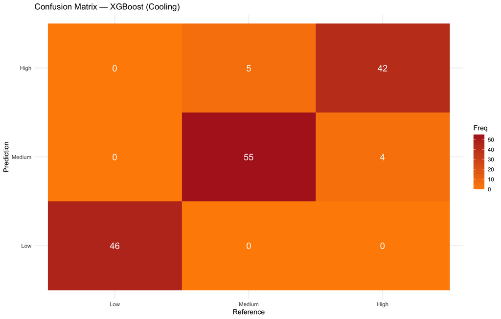

```r
as.data.frame(cl_cm$table) %>%
  ggplot(aes(Reference, Prediction, fill = Freq)) +
  geom_tile() +
  geom_text(aes(label = Freq), colour = "white", size = 5) +
  scale_fill_gradient(low = "darkorange", high = "firebrick") +
  labs(title = paste("Confusion Matrix —", best_cl_name, "(Cooling)")) +
  theme_minimal()
```

### 6.2 ROC / AUC — best cooling model

```r
cl_probs <- predict_probs(best_cl_model, test_CL)
cl_roc   <- multiclass.roc(test_CL$CL_class, as.matrix(cl_probs))
cat("Multiclass AUC (Cooling,", best_cl_name, "):",
    round(as.numeric(cl_roc$auc), 3), "\n")
```

```
## Multiclass AUC (Cooling, XGBoost ): 0.995
```